# SARS-COV2 blood donors serology project

Marc Henrion, Jonathan Mandolo, Brewster Moyo

6 October 2021

## License

This code and its content is made available under an MIT license, (c) 2021 Marc Henrion. See details of the license on the GitHub repository (https://github.com/gitMarcH/Covid19_MBTS_serology).

## Read the data

```r
datFile<-"../20210323_Data/MBTS_data.dta"
datFileNew<-"../20210827_Data/march_july_JM_20210827.csv"
datCorrectionsFile<-"../20210412_DataCorrections/BDCOVID_borderline samples.csv"
datCorrectionsFileNew<-"../20211004_Data/borderlinesamples.csv"
malawiDatFile<-"../20210323_Data/gadm36_MWI_1_sp.rds" # shapefile
datOccupFile<-"../20210521_OccupationData/metadata occupation_.csv"
datPopCensusProjFile<-"../../NSO/Census2018_PopulationProjections/NSO_Census2018_PopulationProjections2018-2021.csv"

# original data
dat<-read.dta13(datFile)
colnames(dat)[colnames(dat)=="donation_date"]<-"date"
dat$date<-ymd(dat$date)
dat$month<-paste(sep="-",year(dat$date),formatC(month(dat$date), width = 2, format = "d", flag = "0"))
dat$results<-factor(as.character(dat$results),levels=c("Negative","Borderline","Positive"))
dat$dob<-ymd(dat$dob)
dat<-dat[dat$date>=ymd("2020-01-01"),]
dat$ODCutoff<-as.numeric(dat$ODCutoff)
dat<-dat %>% mutate(occupation=NA)
dat$gender<-factor(as.character(dat$gender),levels=c("Female","Male")) # just flipping what is the reference level

# new data (2021-03 - 2021-07)
datNew<-read.csv(datFileNew)
datNew$donation_number<-paste(sep="","0",datNew$donation_number)
colnames(datNew)[colnames(datNew)=="donation_date"]<-"date"
#colnames(datNew)[colnames(datNew)=="OD"]<-"ODCutoff"
datNew$date<-dmy(datNew$date)
datNew$dob<-dmy(datNew$dob)
datNew$occupation<-tolower(datNew$occupation)
datNew$gender<-fct_recode(factor(as.character(datNew$gender),levels=c("F","M")),Female="F",Male="M") # just flipping what is the reference level

datNew<-datNew %>%
  mutate(
    month=paste(sep="-",year(date),formatC(month(date), width = 2, format = "d", flag = "0")),
    results=fct_recode(factor(as.character(results),levels=c("neg","borderline","pos")),Negative="neg",Borderline="borderline",Positive="pos")
  ) %>%
  dplyr::select(colnames(dat))

# merge
dat<-bind_rows(dat,datNew) # 5,085 observations

# correct the 17 borderline results with results from different assay
datCorr<-read.csv(datCorrectionsFile)
datCorr$donation<-paste(sep="","0",datCorr$donation)

dat$results[match(datCorr$donation,dat$donation_number)]<-case_when(datCorr$final.result=="neg"~"Negative",datCorr$final.result=="pos"~"Positive")

# correct the 15 borderline samples from the new data
datCorrNew<-read.csv(datCorrectionsFileNew)
datCorrNew$donation_number<-paste(sep="","0",datCorrNew$donation_number)

dat$results[match(datCorrNew$donation_number,dat$donation_number)]<-case_when(datCorrNew$final=="neg"~"Negative",datCorrNew$final=="pos"~"Positive")

dat$results[dat$donation_number=="0784140"]<-"Negative" # as advised by Jonathan in email from 7 May 2021 after asking about this sample given OD=0 yet 'Positive' result
dat$results[dat$donation_number=="0784124"]<-"Positive" # Jonathan confirmed this one was a false negative and should be positive

dat$seropos<-ifelse(dat$results=="Positive",1,0)

datOccup<-read.csv(datOccupFile)
colnames(datOccup)[colnames(datOccup)=="PACK.NUMBER"]<-"donation_number"
datOccup$donation_number<-paste(sep="","0",datOccup$donation_number)
datOccup$OCCUPATION<-tolower(datOccup$OCCUPATION)

dat$occupation[match(datOccup$donation_number,dat$donation_number)]=datOccup$OCCUPATION

# need to correct dates of birth that were mapped to the wrong century given that DOB year was reported only to 2 digits
dat$dob[ymd(dat$dob)>ymd("2020-01-01")]<-gsub(pattern="^20",replacement="19",dat$dob[ymd(dat$dob)>ymd("2020-01-01")])

# need to manually correct 2 dates of birth - as per email from MBTS on 01/09/2021 at 11.03am
dat$dob[dat$donation_number=="0770314"]<-dmy("05/05/2001")
dat$dob[dat$donation_number=="0842762"]<-dmy("08/03/1999")

dat<-dat %>%
  mutate(
    age_calendar=as.period(interval(start=ymd(dob),end=ymd(date))),
    age_years=as.period(interval(start=ymd(dob),end=ymd(date)))$year
  )

# read the census population projection data
datPopCensusProj<-read.csv(datPopCensusProjFile) # these give the mid-year projections - we'll take that to be the 1st of July each year

# calculate population weights from the census data for the adult population in Malawi (maybe 16+ - need to check age range in dataset...)
datPopCensusWeights<-list()

for(mth in sort(unique(dat$month))){
  if(mth=="2020-07"){
    datPopCensusWeights[[mth]]<-datPopCensusProj %>%
      dplyr::filter(Year==2020 & AgeGroup %in% c("15-19","20-24","25-29","30-34","35-39","40-44","45-49","50-54","55-59","60-64"))
  }else if(mth=="2021-07"){
    datPopCensusWeights[[mth]]<-datPopCensusProj %>%
      dplyr::filter(Year==2021 & AgeGroup %in% c("15-19","20-24","25-29","30-34","35-39","40-44","45-49","50-54","55-59","60-64"))
  }else{
    tmp<-as.integer(unlist(strsplit(split="-",mth)))
    yr<-tmp[1]
    mo<-tmp[2]
    w<-1-(((mo-7) %% 12)/12)
    if(mo<7){
      tmp1<-datPopCensusProj %>%
        dplyr::filter(Year==yr-1 & AgeGroup %in% c("15-19","20-24","25-29","30-34","35-39","40-44","45-49","50-54","55-59","60-64"))
      tmp2<-datPopCensusProj %>%
        dplyr::filter(Year==yr & AgeGroup %in% c("15-19","20-24","25-29","30-34","35-39","40-44","45-49","50-54","55-59","60-64"))
    }else{
      tmp1<-datPopCensusProj %>%
        dplyr::filter(Year==yr & AgeGroup %in% c("15-19","20-24","25-29","30-34","35-39","40-44","45-49","50-54","55-59","60-64"))
      tmp2<-datPopCensusProj %>%
        dplyr::filter(Year==yr+1 & AgeGroup %in% c("15-19","20-24","25-29","30-34","35-39","40-44","45-49","50-54","55-59","60-64"))
    }
    datPopCensusWeights[[mth]]<-data.frame(
      Year=yr,
      AgeGroup=tmp1$AgeGroup,
      BothSex=w*tmp1$BothSex+(1-w)*tmp2$BothSex,
      Male=w*tmp1$Male+(1-w)*tmp2$Male,
      Female=w*tmp1$Female+(1-w)*tmp2$Female
    )
  }
}

totPop_15yrs63yrs<-list()
for(mth in names(datPopCensusWeights)){
  totPop_15yrs63yrs[[mth]]<-colSums(datPopCensusWeights[[mth]] %>% dplyr::select(BothSex,Male,Female))

  datPopCensusWeights[[mth]]<-datPopCensusWeights[[mth]] %>% mutate(
    PropBothSex=BothSex/totPop_15yrs63yrs[[mth]]["BothSex"],
    PropMale=Male/totPop_15yrs63yrs[[mth]]["Male"],
    PropFemale=Female/totPop_15yrs63yrs[[mth]]["Female"]
  ) %>%
    pivot_longer(
      cols=c(PropMale,PropFemale),
      names_to="sex",
      values_to="prop" # we will overwrite this
    ) %>%
    mutate(
      prop=case_when(
        sex=="PropMale"~Male/totPop_15yrs63yrs[[mth]]["BothSex"],
        sex=="PropFemale"~Female/totPop_15yrs63yrs[[mth]]["BothSex"]
      )
    )
}

dat<-dat %>% mutate(
  age_group=case_when(
    age_years>=15 & age_years<20~"15-19",
    age_years>=20 & age_years<25~"20-24",
    age_years>=25 & age_years<30~"25-29",
    age_years>=30 & age_years<35~"30-34",
    age_years>=35 & age_years<40~"35-39",
    age_years>=40 & age_years<45~"40-44",
    age_years>=45 & age_years<50~"45-49",
    age_years>=50 & age_years<55~"50-54",
    age_years>=54 & age_years<60~"55-59",
    age_years>=60 & age_years<65~"60-64",
    TRUE~NA_character_
  )
)

datProps<-expand.grid(unique(dat$age_group),unique(dat$gender),unique(dat$month),unique(dat$location))
colnames(datProps)<-c("age_group","sex","month","location")

datProps<-datProps %>%
  mutate(
    prop=NA,
    propCensus=NA,
    sampWeight=NA
  )

for(j in 1:nrow(datProps)){
  datProps$prop[j]<-sum(dat$gender==datProps$sex[j] & dat$age_group==datProps$age_group[j] & dat$month==datProps$month[j] & dat$location==datProps$location[j])/sum(dat$month==datProps$month[j] & dat$location==datProps$location[j])
  datProps$propCensus[j]<-datPopCensusWeights[[datProps$month[j]]]$prop[datPopCensusWeights[[datProps$month[j]]]$AgeGroup==datProps$age_group[j] & datPopCensusWeights[[datProps$month[j]]]$sex==paste(sep="","Prop",datProps$sex[j])]
  datProps$sampWeight[j]<-datProps$propCensus[j]/datProps$prop[j]
}
datProps$sampWeight[abs(datProps$sampWeight)==Inf]<-NA

dat<-dat %>%
  mutate(sampWeight=NA)

for(j in 1:nrow(dat)){
  dat$sampWeight[j]<-datProps$sampWeight[datProps$sex==dat$gender[j] & datProps$age_group==dat$age_group[j] & datProps$month==dat$month[j] & datProps$location==dat$location[j]]
}

datProps<-datProps[order(ym(datProps$month),datProps$sex,datProps$age_group),]

write.csv(dat,row.names=F,quote=F,file=paste(sep="/",outDir,paste(sep="_",gsub(pattern="-",replacement="",Sys.Date()),paste(sep="","MBTS_Covid19_CombinedCleanedData_",gsub(pattern="-",replacement="",Sys.Date()),".csv"))))
```

There are 5085 observations in the dataset, of which 0 have no date information, 0 have no OD information and 0 have no seropositivity status. The date range spans 2020-01-07 to 2021-07-29. There are 0 observations with missing data.

## Assay performance characteristics

There are manufacturer and independently reported sensitivity and specificity for the Wantai SARS-COV2 serology assay. These are given in the table below. For this analysis we are using the independently reported estimates for now.

```r
assaySensMf<-c(251,266)
assaySpecMf<-c(306,306)
assaySensInd<-c(29,30)
assaySpecInd<-c(78,80)

df<-data.frame(
  evaluation=c("Manufacturer","Independent"),
  knSens=c(paste(collapse="/",assaySensMf),paste(collapse="/",assaySensInd)),
  knSpec=c(paste(collapse="/",assaySpecMf),paste(collapse="/",assaySpecInd)),
  sens=c(paste(sep="",format(nsmall=2,round(digits=2,assaySensMf[1]/assaySensMf[2]))," (",paste(collapse=",",format(nsmall=2,round(digits=2,binom.test(assaySensMf[1],assaySensMf[2])$conf.int))),")"),
         paste(sep="",format(nsmall=2,round(digits=2,assaySensInd[1]/assaySensInd[2]))," (",paste(collapse=",",format(nsmall=2,round(digits=2,binom.test(assaySensInd[1],assaySensInd[2])$conf.int))),")")),
  spec=c(paste(sep="",format(nsmall=2,round(digits=2,assaySpecMf[1]/assaySpecMf[2]))," (",paste(collapse=",",format(nsmall=2,round(digits=2,binom.test(assaySpecMf[1],assaySpecMf[2])$conf.int))),")"),
         paste(sep="",format(nsmall=2,round(digits=2,assaySpecInd[1]/assaySpecInd[2]))," (",paste(collapse=",",format(nsmall=2,round(digits=2,binom.test(assaySpecInd[1],assaySpecInd[2])$conf.int))),")"))
)

df %>%
  kable(col.names = c("","k/n (sensitivity)","k/n (specificity)","sensitivity (95% CI)","specificity (95% CI)")) %>%
  kable_styling(full_width=FALSE)
```

|  | k/n (sensitivity) | k/n (specificity) | sensitivity (95% CI) | specificity (95% CI) |
| --- | --- | --- | --- | --- |
| Manufacturer | 251/266 | 306/306 | 0.94 (0.91,0.97) | 1.00 (0.99,1.00) |
| Independent | 29/30 | 78/80 | 0.97 (0.83,1.00) | 0.98 (0.91,1.00) |

## Population weights calculated from census data

We will use the National Statistics Office (NSO) 2018 Malawi Population and Housing Census Population Projections 2018-2050 estimates for 2019, 2020 and 2021 to calculate post-stratification population weights (the projections are for the mid-year point and we linearly interpolate on a monthly basis). These weights take 5-year age group, sex and month of donation into account. Month of donation is included as the age group and sex distribution of the donations can change considerably from month to month. The age range in the MBTS data spans from 15 years to 63 years. For this reason we used 5-year age band from 15-19 up to 60-64. The total population size is calculated for these age bands only.

```r
head(datProps,n=20) %>%
  kable(col.names=c("Age group","Sex","Month of donation","Location","Proportion of age-sex group in MBTS data","Proportion of age-sex group in census projection","Population weight"),digits=4) %>%
  kable_styling(full_width = FALSE)
```

|  | Age group | Sex | Month of donation | Location | Proportion of age-sex group in MBTS data | Proportion of age-sex group in census projection | Population weight |
| --- | --- | --- | --- | --- | --- | --- | --- |
| 51 | 35-39 | Female | 2020-01 | Lilongwe | 0.1200 | 0.0514 | 0.4280 |
| 431 | 35-39 | Female | 2020-01 | Blantyre | 0.0196 | 0.0514 | 2.6196 |
| 811 | 35-39 | Female | 2020-01 | Mzuzu | 0.0339 | 0.0514 | 1.5153 |
| 1191 | 35-39 | Female | 2020-01 | Balaka | 0.0000 | 0.0514 | NA |
| 52 | 40-44 | Female | 2020-01 | Lilongwe | 0.0200 | 0.0406 | 2.0308 |
| 432 | 40-44 | Female | 2020-01 | Blantyre | 0.0588 | 0.0406 | 0.6905 |
| 812 | 40-44 | Female | 2020-01 | Mzuzu | 0.0339 | 0.0406 | 1.1982 |
| 1192 | 40-44 | Female | 2020-01 | Balaka | 0.0149 | 0.0406 | 2.7213 |
| 53 | 20-24 | Female | 2020-01 | Lilongwe | 0.1200 | 0.0921 | 0.7672 |
| 433 | 20-24 | Female | 2020-01 | Blantyre | 0.0392 | 0.0921 | 2.3478 |
| 813 | 20-24 | Female | 2020-01 | Mzuzu | 0.0508 | 0.0921 | 1.8107 |
| 1193 | 20-24 | Female | 2020-01 | Balaka | 0.0746 | 0.0921 | 1.2337 |
| 54 | 25-29 | Female | 2020-01 | Lilongwe | 0.0800 | 0.0773 | 0.9665 |
| 434 | 25-29 | Female | 2020-01 | Blantyre | 0.0784 | 0.0773 | 0.9858 |
| 814 | 25-29 | Female | 2020-01 | Mzuzu | 0.0169 | 0.0773 | 4.5618 |
| 1194 | 25-29 | Female | 2020-01 | Balaka | 0.0000 | 0.0773 | NA |
| 55 | 30-34 | Female | 2020-01 | Lilongwe | 0.0400 | 0.0632 | 1.5793 |
| 435 | 30-34 | Female | 2020-01 | Blantyre | 0.0392 | 0.0632 | 1.6108 |
| 815 | 30-34 | Female | 2020-01 | Mzuzu | 0.0000 | 0.0632 | NA |
| 1195 | 30-34 | Female | 2020-01 | Balaka | 0.0000 | 0.0632 | NA |

## Data summary

A quick summary of some of the variables in the dataset are listed below, stratified by time & place.

```r
sumAll<-dat %>%
  dplyr::summarise(n_total = n(),
            age_median = format(nsmall=1,round(digits=1,median(age))),
            age_IQR = paste(sep="","(",paste(collapse=",",format(nsmall=1,round(digits=1,quantile(age,probs=c(0.25,0.75))))),")"),
            female_perc = paste(sep="",format(nsmall=1,round(digits=1,100*sum(gender == "Female")/sum(!is.na(gender)))),"%"),
            seropos_n=sum(seropos==1),
            seropos_prop=sum(seropos==1)/sum(!is.na(seropos))
)
sumAll<-sumAll %>% mutate(seropos_propAdj=adjPrevSensSpec(seropos_prop, assaySensInd[1]/assaySensInd[2], assaySpecInd[1]/assaySpecInd[2], replaceImpossibleValues = TRUE))
sumAll$seropos_prop<-paste(sep="",format(nsmall=1,round(digits=1,100*sumAll$seropos_prop)),"%")
sumAll$seropos_propAdj<-paste(sep="",format(nsmall=1,round(digits=1,100*sumAll$seropos_propAdj)),"%")

sumLocation<-dat %>%
  group_by(location) %>%
  dplyr::summarise(n_total = n(),
            age_median = format(nsmall=1,round(digits=1,median(age))),
            age_IQR = paste(sep="","(",paste(collapse=",",format(nsmall=1,round(digits=1,quantile(age,probs=c(0.25,0.75))))),")"),
            female_perc = paste(sep="",format(nsmall=1,round(digits=1,100*sum(gender == "Female")/sum(!is.na(gender)))),"%"),
            seropos_n=sum(seropos==1),
            seropos_prop=sum(seropos==1)/sum(!is.na(seropos))
)
sumLocation<-sumLocation %>% mutate(seropos_propAdj=adjPrevSensSpec(seropos_prop, assaySensInd[1]/assaySensInd[2], assaySpecInd[1]/assaySpecInd[2], replaceImpossibleValues = TRUE))
sumLocation$seropos_prop<-paste(sep="",format(nsmall=1,round(digits=1,100*sumLocation$seropos_prop)),"%")
sumLocation$seropos_propAdj<-paste(sep="",format(nsmall=1,round(digits=1,100*sumLocation$seropos_propAdj)),"%")

sumLocation<-rbind(
  data.frame(location="All samples",sumAll),
  sumLocation
)

# sumLocation %>%
#   dplyr::select(!seropos_prop) %>%
#   kable(col.names=c("Location","Number of samples","Age (median)","Age (IQR)","Females (%)","Seropositives (frequency)","Seropositives, adjusted (%)"),caption="Summary statistics for all samples and by location over the entire period (2020-01 to 2021-07). The seropositive percentage has been adjusted for the assay sensitivity and specificity.") %>%
#   kable_styling(full_width = FALSE)

sumMonth<-dat %>%
  group_by(month) %>%
  dplyr::summarise(n_total = n(),
            age_median = format(nsmall=1,round(digits=1,median(age))),
            age_IQR = paste(sep="","(",paste(collapse=",",format(nsmall=1,round(digits=1,quantile(age,probs=c(0.25,0.75))))),")"),
            female_perc = paste(sep="",format(nsmall=1,round(digits=1,100*sum(gender == "Female")/sum(!is.na(gender)))),"%"),
            seropos_n=sum(seropos==1),
            seropos_prop=sum(seropos==1)/sum(!is.na(seropos))
)
sumMonth<-sumMonth %>% mutate(seropos_propAdj=adjPrevSensSpec(seropos_prop, assaySensInd[1]/assaySensInd[2], assaySpecInd[1]/assaySpecInd[2], replaceImpossibleValues = TRUE))
sumMonth$seropos_prop<-paste(sep="",format(nsmall=1,round(digits=1,100*sumMonth$seropos_prop)),"%")
sumMonth$seropos_propAdj<-paste(sep="",format(nsmall=1,round(digits=1,100*sumMonth$seropos_propAdj)),"%")

sumMonth<-data.frame(location="All samples",sumMonth)

sumMonthLocation<-list()
for(loc in sort(unique(dat$location))){
  sumMonthLocation[[loc]]<-dat %>%
    dplyr::filter(location==loc) %>%
    group_by(month) %>%
    dplyr::summarise(n_total = n(),
                     age_median = format(nsmall=1,round(digits=1,median(age))),
                     age_IQR = paste(sep="","(",paste(collapse=",",format(nsmall=1,round(digits=1,quantile(age,probs=c(0.25,0.75))))),")"),
                     female_perc = paste(sep="",format(nsmall=1,round(digits=1,100*sum(gender == "Female")/sum(!is.na(gender)))),"%"),
                     seropos_n=sum(seropos==1),
                     seropos_prop=sum(seropos==1)/sum(!is.na(seropos))
    )
  sumMonthLocation[[loc]]<-sumMonthLocation[[loc]] %>% mutate(seropos_propAdj=adjPrevSensSpec(seropos_prop, assaySensInd[1]/assaySensInd[2], assaySpecInd[1]/assaySpecInd[2], replaceImpossibleValues = TRUE))
  sumMonthLocation[[loc]]$seropos_prop<-paste(sep="",format(nsmall=1,round(digits=1,100*sumMonthLocation[[loc]]$seropos_prop)),"%")
  sumMonthLocation[[loc]]$seropos_propAdj<-paste(sep="",format(nsmall=1,round(digits=1,100*sumMonthLocation[[loc]]$seropos_propAdj)),"%")

  #colnames(sumMonthLocation[[loc]])[-1]<-paste(sep=".",colnames(sumMonthLocation[[loc]])[-1],loc)
  #sumMonth<-left_join(sumMonth,sumMonthLocation[[loc]],by="month")
  sumMonth<-rbind(sumMonth,data.frame(location=loc,sumMonthLocation[[loc]]))
}
```

```r
datPropAll<-dat %>%
  dplyr::summarise(seroposprop=mean(seropos),
            seropospropLow=binom.test(sum(seropos),n())$conf.int[1],
            seropospropHigh=binom.test(sum(seropos),n())$conf.int[2],.groups="drop")

for(i in 1:nrow(datPropAll)){
  tmp<-adjPrevSensSpecCI(prevCI=c(datPropAll$seropospropLow[i],datPropAll$seropospropHigh[i]),
                         sensCI=binom.test(assaySensInd[1],assaySensInd[2])$conf.int,
                         specCI=binom.test(assaySpecInd[1],assaySpecInd[2])$conf.int,
                         prev=datPropAll$seroposprop[i],
                         sens=assaySensInd[1]/assaySensInd[2],
                         spec=assaySpecInd[1]/assaySpecInd[2],
                         N=1e5)
  datPropAll$seropospropAdj[i]<-tmp$estimate
  datPropAll$seropospropAdjLow[i]<-tmp$conf.int[1]
  datPropAll$seropospropAdjHigh[i]<-tmp$conf.int[2]
}

datProp<-dat %>%
  group_by(month) %>%
  dplyr::summarise(seroposprop=mean(seropos),
            seropospropLow=binom.test(sum(seropos),n())$conf.int[1],
            seropospropHigh=binom.test(sum(seropos),n())$conf.int[2],.groups="drop")

datProp$seropospropAdj<-NA
datProp$seropospropAdjLow<-NA
datProp$seropospropAdjHigh<-NA

for(i in 1:nrow(datProp)){
  tmp<-adjPrevSensSpecCI(prevCI=c(datProp$seropospropLow[i],datProp$seropospropHigh[i]),
                         sensCI=binom.test(assaySensInd[1],assaySensInd[2])$conf.int,
                         specCI=binom.test(assaySpecInd[1],assaySpecInd[2])$conf.int,
                         prev=datProp$seroposprop[i],
                         sens=assaySensInd[1]/assaySensInd[2],
                         spec=assaySpecInd[1]/assaySpecInd[2],
                         N=1e5)
  datProp$seropospropAdj[i]<-tmp$estimate
  datProp$seropospropAdjLow[i]<-tmp$conf.int[1]
  datProp$seropospropAdjHigh[i]<-tmp$conf.int[2]
}

# datProp$seropospropAdjLow[datProp$seropospropAdjLow<=0 | datProp$seropospropAdj<=0]<-0
# datProp$seropospropAdj[datProp$seropospropAdj<=0]<-0

datPropStrat<-dat %>%
  group_by(month,location) %>%
  dplyr::summarise(seroposprop=mean(seropos),
            seropospropLow=binom.test(sum(seropos),n())$conf.int[1],
            seropospropHigh=binom.test(sum(seropos),n())$conf.int[2],.groups="drop")

datPropStrat$seropospropAdj<-NA
datPropStrat$seropospropAdjLow<-NA
datPropStrat$seropospropAdjHigh<-NA

for(i in 1:nrow(datPropStrat)){
  tmp<-adjPrevSensSpecCI(prevCI=c(datPropStrat$seropospropLow[i],datPropStrat$seropospropHigh[i]),
                         sensCI=binom.test(assaySensInd[1],assaySensInd[2])$conf.int,
                         specCI=binom.test(assaySpecInd[1],assaySpecInd[2])$conf.int,
                         prev=datPropStrat$seroposprop[i],
                         sens=assaySensInd[1]/assaySensInd[2],
                         spec=assaySpecInd[1]/assaySpecInd[2],
                         N=1e6)
  datPropStrat$seropospropAdj[i]<-tmp$estimate
  datPropStrat$seropospropAdjLow[i]<-tmp$conf.int[1]
  datPropStrat$seropospropAdjHigh[i]<-tmp$conf.int[2]
}

# datPropStrat$seropospropAdjLow[datPropStrat$seropospropAdjLow<=0 | datPropStrat$seropospropAdj<=0]<-0
# datPropStrat$seropospropAdj[datPropStrat$seropospropAdj<=0]<-0

datPropBl<-datPropStrat %>% dplyr::filter(location=="Balaka")
datPropBt<-datPropStrat %>% dplyr::filter(location=="Blantyre")
datPropLl<-datPropStrat %>% dplyr::filter(location=="Lilongwe")
datPropMz<-datPropStrat %>% dplyr::filter(location=="Mzuzu")


tab2Paper<-data.frame(
  month=gsub(seq(ym("2020-01"),ym("2021-07"),by="month"),pattern="-01$",replacement=""),
  Balaka=NA,
  Blantyre=NA,
  Lilongwe=NA,
  Mzuzu=NA,
  Total=NA
) %>%
  mutate(
    Balaka=paste(sep="",format(nsmall=1,round(digits=1,100*datPropBl$seropospropAdj[match(month,datPropBl$month)])),"% (",format(nsmall=1,round(digits=1,100*datPropBl$seropospropAdjLow[match(month,datPropBl$month)])),"%,",format(nsmall=1,round(digits=1,100*datPropBl$seropospropAdjHigh[match(month,datPropBl$month)])),"%)"),
    Blantyre=paste(sep="",format(nsmall=1,round(digits=1,100*datPropBt$seropospropAdj[match(month,datPropBt$month)])),"% (",format(nsmall=1,round(digits=1,100*datPropBt$seropospropAdjLow[match(month,datPropBt$month)])),"%,",format(nsmall=1,round(digits=1,100*datPropBt$seropospropAdjHigh[match(month,datPropBt$month)])),"%)"),
    Lilongwe=paste(sep="",format(nsmall=1,round(digits=1,100*datPropLl$seropospropAdj[match(month,datPropLl$month)])),"% (",format(nsmall=1,round(digits=1,100*datPropLl$seropospropAdjLow[match(month,datPropLl$month)])),"%,",format(nsmall=1,round(digits=1,100*datPropLl$seropospropAdjHigh[match(month,datPropLl$month)])),"%)"),
    Mzuzu=paste(sep="",format(nsmall=1,round(digits=1,100*datPropMz$seropospropAdj[match(month,datPropMz$month)])),"% (",format(nsmall=1,round(digits=1,100*datPropMz$seropospropAdjLow[match(month,datPropMz$month)])),"%,",format(nsmall=1,round(digits=1,100*datPropMz$seropospropAdjHigh[match(month,datPropMz$month)])),"%)"),
    Total=paste(sep="",format(nsmall=1,round(digits=1,100*datProp$seropospropAdj[match(month,datProp$month)])),"% (",format(nsmall=1,round(digits=1,100*datProp$seropospropAdjLow[match(month,datProp$month)])),"%,",format(nsmall=1,round(digits=1,100*datProp$seropospropAdjHigh[match(month,datProp$month)])),"%)")
  )

write.csv(tab2Paper,row.names=F,file=paste(sep="/",outDir,paste(sep="_",gsub(pattern="-",replacement="",Sys.Date()),"Tab2_AdjustedPrevlaenceEstimates_StratifiedByLocation.csv")))
```

```r
# apply sample weights to overall seroprevalence
datPropAllSampWeight<-dat %>%
  dplyr::summarise(seroposprop=sum(seropos*sampWeight)/sum(sampWeight),
            seropospropLow=binom.test(x=round(sum(seropos*sampWeight)*(n()/sum(sampWeight))),n=n())$conf.int[1],
            seropospropHigh=binom.test(x=round(sum(seropos*sampWeight)*(n()/sum(sampWeight))),n=n())$conf.int[2],.groups="drop")

for(i in 1:nrow(datPropAllSampWeight)){
  tmp<-adjPrevSensSpecCI(prevCI=c(datPropAllSampWeight$seropospropLow[i],datPropAllSampWeight$seropospropHigh[i]),
                         sensCI=binom.test(assaySensInd[1],assaySensInd[2])$conf.int,
                         specCI=binom.test(assaySpecInd[1],assaySpecInd[2])$conf.int,
                         prev=datPropAllSampWeight$seroposprop[i],
                         sens=assaySensInd[1]/assaySensInd[2],
                         spec=assaySpecInd[1]/assaySpecInd[2],
                         N=1e5)
  datPropAllSampWeight$seropospropAdj[i]<-tmp$estimate
  datPropAllSampWeight$seropospropAdjLow[i]<-tmp$conf.int[1]
  datPropAllSampWeight$seropospropAdjHigh[i]<-tmp$conf.int[2]
}

# apply sample weights to monthly seroprevalence
datPropMonthSampWeight<-dat %>%
  group_by(month) %>%
  dplyr::summarise(seroposprop=sum(seropos*sampWeight)/sum(sampWeight),
            seropospropLow=binom.test(x=round(sum(seropos*sampWeight)*(n()/sum(sampWeight))),n=n())$conf.int[1],
            seropospropHigh=binom.test(x=round(sum(seropos*sampWeight)*(n()/sum(sampWeight))),n=n())$conf.int[2],.groups="drop")

datPropMonthSampWeight$seropospropAdj<-NA
datPropMonthSampWeight$seropospropAdjLow<-NA
datPropMonthSampWeight$seropospropAdjHigh<-NA

for(i in 1:nrow(datPropMonthSampWeight)){
  tmp<-adjPrevSensSpecCI(prevCI=c(datPropMonthSampWeight$seropospropLow[i],datPropMonthSampWeight$seropospropHigh[i]),
                         sensCI=binom.test(assaySensInd[1],assaySensInd[2])$conf.int,
                         specCI=binom.test(assaySpecInd[1],assaySpecInd[2])$conf.int,
                         prev=datPropMonthSampWeight$seroposprop[i],
                         sens=assaySensInd[1]/assaySensInd[2],
                         spec=assaySpecInd[1]/assaySpecInd[2],
                         N=1e5)
  datPropMonthSampWeight$seropospropAdj[i]<-tmp$estimate
  datPropMonthSampWeight$seropospropAdjLow[i]<-tmp$conf.int[1]
  datPropMonthSampWeight$seropospropAdjHigh[i]<-tmp$conf.int[2]
}

datPropStratSampWeight<-dat %>%
  group_by(month,location) %>%
  dplyr::summarise(seroposprop=sum(seropos*sampWeight)/sum(sampWeight),
            seropospropLow=binom.test(x=round(sum(seropos*sampWeight)*(n()/sum(sampWeight))),n=n())$conf.int[1],
            seropospropHigh=binom.test(x=round(sum(seropos*sampWeight)*(n()/sum(sampWeight))),n=n())$conf.int[2],.groups="drop")

datPropStratSampWeight$seropospropAdj<-NA
datPropStratSampWeight$seropospropAdjLow<-NA
datPropStratSampWeight$seropospropAdjHigh<-NA

for(i in 1:nrow(datPropStratSampWeight)){
  tmp<-adjPrevSensSpecCI(prevCI=c(datPropStratSampWeight$seropospropLow[i],datPropStratSampWeight$seropospropHigh[i]),
                         sensCI=binom.test(assaySensInd[1],assaySensInd[2])$conf.int,
                         specCI=binom.test(assaySpecInd[1],assaySpecInd[2])$conf.int,
                         prev=datPropStratSampWeight$seroposprop[i],
                         sens=assaySensInd[1]/assaySensInd[2],
                         spec=assaySpecInd[1]/assaySpecInd[2],
                         N=1e6)
  datPropStratSampWeight$seropospropAdj[i]<-tmp$estimate
  datPropStratSampWeight$seropospropAdjLow[i]<-tmp$conf.int[1]
  datPropStratSampWeight$seropospropAdjHigh[i]<-tmp$conf.int[2]
}

sumMonthWeighted<-sumMonth %>%
  dplyr::filter(location=="All samples") %>%
  dplyr::select(!location) %>%
  mutate(
    seropos_propAdj_Weighted=paste(sep="",format(nsmall=1,round(digits=1,100*datPropMonthSampWeight$seropospropAdj[match(month,datPropMonthSampWeight$month)])),"%")
  )

sumMonthWeighted %>%
  dplyr::select(!age_IQR) %>%
  kable(col.names=c("Month","Samples (freq.)","Age (median)","Females (%)","Seropositives (freq.)","Seropositives, unadj. (%)", "Seropositives, adj, (%)", "Seropositives, weighted & adj. (%)"),
        caption="Summary statistics for samples (across all sites) per month. The unadjusted, adjusted (for assay sensitivity and specificity) but unweighted and adjusted & weighted (by population weights derived from census data) seropositive percentages are shown.",align = "r") %>%
  kable_styling(full_width = FALSE)
```

Summary statistics for samples (across all sites) per month. The unadjusted, adjusted (for assay sensitivity and specificity) but unweighted and adjusted & weighted (by population weights derived from census data) seropositive percentages are shown.

| Month | Samples (freq.) | Age (median) | Females (%) | Seropositives (freq.) | Seropositives, unadj. (%) | Seropositives, adj, (%) | Seropositives, weighted & adj. (%) |
| --- | --- | --- | --- | --- | --- | --- | --- |
| 2020-01 | 227 | 23.7 | 33.9% | 0 | 0.0% | 0.0% | 0.0% |
| 2020-02 | 194 | 23.9 | 23.2% | 1 | 0.5% | 0.0% | 0.0% |
| 2020-03 | 199 | 25.0 | 35.7% | 2 | 1.0% | 0.0% | 0.0% |
| 2020-04 | 205 | 26.2 | 21.0% | 1 | 0.5% | 0.0% | 0.0% |
| 2020-05 | 194 | 25.9 | 22.2% | 4 | 2.1% | 0.0% | 0.0% |
| 2020-06 | 242 | 29.1 | 31.8% | 3 | 1.2% | 0.0% | 0.0% |
| 2020-07 | 204 | 28.6 | 43.1% | 17 | 8.3% | 6.2% | 6.8% |
| 2020-08 | 192 | 29.7 | 34.9% | 20 | 10.4% | 8.4% | 5.6% |
| 2020-09 | 309 | 27.3 | 22.0% | 35 | 11.3% | 9.4% | 11.8% |
| 2020-10 | 324 | 26.0 | 23.8% | 56 | 17.3% | 15.7% | 18.5% |
| 2020-11 | 365 | 21.8 | 19.5% | 45 | 12.3% | 10.4% | 10.2% |
| 2020-12 | 263 | 20.8 | 14.8% | 29 | 11.0% | 9.1% | 8.0% |
| 2021-01 | 303 | 26.9 | 17.5% | 76 | 25.1% | 24.0% | 24.0% |
| 2021-02 | 365 | 26.6 | 22.5% | 180 | 49.3% | 49.7% | 51.5% |
| 2021-03 | 298 | 24.8 | 35.6% | 161 | 54.0% | 54.7% | 55.7% |
| 2021-04 | 296 | 23.0 | 37.2% | 193 | 65.2% | 66.6% | 61.6% |
| 2021-05 | 298 | 25.7 | 37.9% | 187 | 62.8% | 64.0% | 64.9% |
| 2021-06 | 319 | 22.6 | 37.9% | 207 | 64.9% | 66.3% | 64.9% |
| 2021-07 | 288 | 24.4 | 14.6% | 184 | 63.9% | 65.2% | 70.2% |

```r
datPropBl<-datPropStratSampWeight %>% dplyr::filter(location=="Balaka")
datPropBt<-datPropStratSampWeight %>% dplyr::filter(location=="Blantyre")
datPropLl<-datPropStratSampWeight %>% dplyr::filter(location=="Lilongwe")
datPropMz<-datPropStratSampWeight %>% dplyr::filter(location=="Mzuzu")

tab2Paper<-data.frame(
  month=gsub(seq(ym("2020-01"),ym("2021-07"),by="month"),pattern="-01$",replacement=""),
  Balaka=NA,
  Blantyre=NA,
  Lilongwe=NA,
  Mzuzu=NA,
  Total=NA,
  TotalWeighted=NA
) %>%
  mutate(
    Balaka=paste(sep="",format(nsmall=1,round(digits=1,100*datPropBl$seropospropAdj[match(month,datPropBl$month)])),"% (",format(nsmall=1,round(digits=1,100*datPropBl$seropospropAdjLow[match(month,datPropBl$month)])),"%,",format(nsmall=1,round(digits=1,100*datPropBl$seropospropAdjHigh[match(month,datPropBl$month)])),"%)"),
    Blantyre=paste(sep="",format(nsmall=1,round(digits=1,100*datPropBt$seropospropAdj[match(month,datPropBt$month)])),"% (",format(nsmall=1,round(digits=1,100*datPropBt$seropospropAdjLow[match(month,datPropBt$month)])),"%,",format(nsmall=1,round(digits=1,100*datPropBt$seropospropAdjHigh[match(month,datPropBt$month)])),"%)"),
    Lilongwe=paste(sep="",format(nsmall=1,round(digits=1,100*datPropLl$seropospropAdj[match(month,datPropLl$month)])),"% (",format(nsmall=1,round(digits=1,100*datPropLl$seropospropAdjLow[match(month,datPropLl$month)])),"%,",format(nsmall=1,round(digits=1,100*datPropLl$seropospropAdjHigh[match(month,datPropLl$month)])),"%)"),
    Mzuzu=paste(sep="",format(nsmall=1,round(digits=1,100*datPropMz$seropospropAdj[match(month,datPropMz$month)])),"% (",format(nsmall=1,round(digits=1,100*datPropMz$seropospropAdjLow[match(month,datPropMz$month)])),"%,",format(nsmall=1,round(digits=1,100*datPropMz$seropospropAdjHigh[match(month,datPropMz$month)])),"%)"),
    Total=paste(sep="",format(nsmall=1,round(digits=1,100*datProp$seropospropAdj[match(month,datProp$month)])),"% (",format(nsmall=1,round(digits=1,100*datProp$seropospropAdjLow[match(month,datProp$month)])),"%,",format(nsmall=1,round(digits=1,100*datProp$seropospropAdjHigh[match(month,datProp$month)])),"%)"),
    TotalWeighted=paste(sep="",format(nsmall=1,round(digits=1,100*datPropMonthSampWeight$seropospropAdj[match(month,datPropMonthSampWeight$month)])),"% (",format(nsmall=1,round(digits=1,100*datPropMonthSampWeight$seropospropAdjLow[match(month,datPropMonthSampWeight$month)])),"%,",format(nsmall=1,round(digits=1,100*datPropMonthSampWeight$seropospropAdjHigh[match(month,datPropMonthSampWeight$month)])),"%)")
  )

write.csv(tab2Paper,row.names=F,file=paste(sep="/",outDir,paste(sep="_",gsub(pattern="-",replacement="",Sys.Date()),"Tab2_AdjustedPrevlaenceEstimates_StratifiedByLocation_Weighted.csv")))

# apply sample weights to monthly seroprevalence by location
datPropLocSampWeight<-dat %>%
  group_by(location,month) %>%
  dplyr::summarise(seroposprop=sum(seropos*sampWeight)/sum(sampWeight),
            seropospropLow=binom.test(x=round(sum(seropos*sampWeight)*(n()/sum(sampWeight))),n=n())$conf.int[1],
            seropospropHigh=binom.test(x=round(sum(seropos*sampWeight)*(n()/sum(sampWeight))),n=n())$conf.int[2],.groups="drop")

datPropLocSampWeight$seropospropAdj<-NA
datPropLocSampWeight$seropospropAdjLow<-NA
datPropLocSampWeight$seropospropAdjHigh<-NA

for(i in 1:nrow(datPropLocSampWeight)){
  tmp<-adjPrevSensSpecCI(prevCI=c(datPropLocSampWeight$seropospropLow[i],datPropLocSampWeight$seropospropHigh[i]),
                         sensCI=binom.test(assaySensInd[1],assaySensInd[2])$conf.int,
                         specCI=binom.test(assaySpecInd[1],assaySpecInd[2])$conf.int,
                         prev=datPropLocSampWeight$seroposprop[i],
                         sens=assaySensInd[1]/assaySensInd[2],
                         spec=assaySpecInd[1]/assaySpecInd[2],
                         N=1e5)
  datPropLocSampWeight$seropospropAdj[i]<-tmp$estimate
  datPropLocSampWeight$seropospropAdjLow[i]<-tmp$conf.int[1]
  datPropLocSampWeight$seropospropAdjHigh[i]<-tmp$conf.int[2]
}

sumLocWeighted<-sumMonth %>%
  mutate(
    seropos_propAdj_Weighted=NA
  )

for(j in 1:nrow(sumLocWeighted)){
  if(sumLocWeighted$location[j]!="All samples"){
    sumLocWeighted$seropos_propAdj_Weighted[j]<-paste(sep="",format(nsmall=1,round(digits=1,100*datPropLocSampWeight$seropospropAdj[datPropLocSampWeight$month==sumLocWeighted$month[j] & datPropLocSampWeight$location==sumLocWeighted$location[j]])),"%")
  }else{
    sumLocWeighted$seropos_propAdj_Weighted[j]<-paste(sep="",format(nsmall=1,round(digits=1,100*datPropMonthSampWeight$seropospropAdj[datPropMonthSampWeight$month==sumLocWeighted$month[j]])),"%")
  }
}
```

```r
# idxAll<-which(sumMonth$location=="All samples")
# idxBalaka<-which(sumMonth$location=="Balaka")
# idxBlantyre<-which(sumMonth$location=="Blantyre")
# idxLilongwe<-which(sumMonth$location=="Lilongwe")
# idxMzuzu<-which(sumMonth$location=="Mzuzu")
#
# sumMonth %>%
#   dplyr::select(!c(location,seropos_prop)) %>%
#   kable(col.names=c("Month","Number of samples","Age (median)","Age (IQR)","Females (%)","Seropositives (frequency)", "Seropositives, adjusted (%)"),
#         caption="Summary statistics for samples per site and month. The seropositive percentage has been adjusted for the assay sensitivity and specificity.",align = "r") %>%
#   kable_styling(full_width = FALSE) %>%
#   pack_rows("All samples",min(idxAll),max(idxAll)) %>%
#   pack_rows("Balaka",min(idxBalaka),max(idxBalaka)) %>%
#   pack_rows("Blantyre",min(idxBlantyre),max(idxBlantyre)) %>%
#   pack_rows("Lilongwe",min(idxLilongwe),max(idxLilongwe)) %>%
#   pack_rows("Mzuzu",min(idxMzuzu),max(idxMzuzu))

idxAll<-which(sumLocWeighted$location=="All samples")
idxBalaka<-which(sumLocWeighted$location=="Balaka")
idxBlantyre<-which(sumLocWeighted$location=="Blantyre")
idxLilongwe<-which(sumLocWeighted$location=="Lilongwe")
idxMzuzu<-which(sumLocWeighted$location=="Mzuzu")

sumLocWeighted %>%
  dplyr::select(!c(location,seropos_prop,seropos_propAdj)) %>%
  kable(col.names=c("Month","Number of samples","Age (median)","Age (IQR)","Females (%)","Seropositives (frequency)", "Seropositives, adjusted, weighted (%)"),
        caption="Summary statistics for samples per site and month. The seropositive percentage has been adjusted for the assay sensitivity and specificity and population weights.",align = "r") %>%
  kable_styling(full_width = FALSE) %>%
  pack_rows("All samples",min(idxAll),max(idxAll)) %>%
  pack_rows("Balaka",min(idxBalaka),max(idxBalaka)) %>%
  pack_rows("Blantyre",min(idxBlantyre),max(idxBlantyre)) %>%
  pack_rows("Lilongwe",min(idxLilongwe),max(idxLilongwe)) %>%
  pack_rows("Mzuzu",min(idxMzuzu),max(idxMzuzu))
```

Summary statistics for samples per site and month. The seropositive percentage has been adjusted for the assay sensitivity and specificity and population weights.

| Month | Number of samples | Age (median) | Age (IQR) | Females (%) | Seropositives (frequency) | Seropositives, adjusted, weighted (%) |
| --- | --- | --- | --- | --- | --- | --- |
| **All samples** |  |  |  |  |  |  |
| 2020-01 | 227 | 23.7 | (19.7,32.2) | 33.9% | 0 | 0.0% |
| 2020-02 | 194 | 23.9 | (20.0,30.7) | 23.2% | 1 | 0.0% |
| 2020-03 | 199 | 25.0 | (20.2,30.4) | 35.7% | 2 | 0.0% |
| 2020-04 | 205 | 26.2 | (21.7,34.9) | 21.0% | 1 | 0.0% |
| 2020-05 | 194 | 25.9 | (21.7,35.3) | 22.2% | 4 | 0.0% |
| 2020-06 | 242 | 29.1 | (22.5,36.5) | 31.8% | 3 | 0.0% |
| 2020-07 | 204 | 28.6 | (23.1,37.8) | 43.1% | 17 | 6.8% |
| 2020-08 | 192 | 29.7 | (22.7,39.2) | 34.9% | 20 | 5.6% |
| 2020-09 | 309 | 27.3 | (21.1,36.2) | 22.0% | 35 | 11.8% |
| 2020-10 | 324 | 26.0 | (20.7,35.1) | 23.8% | 56 | 18.5% |
| 2020-11 | 365 | 21.8 | (19.9,30.1) | 19.5% | 45 | 10.2% |
| 2020-12 | 263 | 20.8 | (19.9,26.5) | 14.8% | 29 | 8.0% |
| 2021-01 | 303 | 26.9 | (22.0,33.8) | 17.5% | 76 | 24.0% |
| 2021-02 | 365 | 26.6 | (21.6,33.3) | 22.5% | 180 | 51.5% |
| 2021-03 | 298 | 24.8 | (20.4,30.7) | 35.6% | 161 | 55.7% |
| 2021-04 | 296 | 23.0 | (19.2,29.8) | 37.2% | 193 | 61.6% |
| 2021-05 | 298 | 25.7 | (21.5,34.2) | 37.9% | 187 | 64.9% |
| 2021-06 | 319 | 22.6 | (19.0,31.8) | 37.9% | 207 | 64.9% |
| 2021-07 | 288 | 24.4 | (20.5,31.2) | 14.6% | 184 | 70.2% |
| **Balaka** |  |  |  |  |  |  |
| 2020-01 | 67 | 19.4 | (19.1,20.0) | 46.3% | 0 | 0.0% |
| 2020-02 | 49 | 19.8 | (19.3,20.1) | 26.5% | 1 | 0.0% |
| 2020-03 | 50 | 19.9 | (19.3,21.1) | 50.0% | 0 | 0.0% |
| 2020-04 | 68 | 22.9 | (20.0,27.4) | 22.1% | 1 | 0.0% |
| 2020-05 | 49 | 23.1 | (20.3,35.3) | 4.1% | 1 | 0.0% |
| 2020-06 | 53 | 25.3 | (20.7,29.1) | 35.8% | 0 | 0.0% |
| 2020-07 | 54 | 23.7 | (21.6,28.3) | 50.0% | 0 | 0.0% |
| 2020-08 | 70 | 24.2 | (20.7,34.7) | 32.9% | 1 | 0.0% |
| 2020-09 | 65 | 21.0 | (20.2,26.7) | 20.0% | 0 | 0.0% |

[output cut: 70 more lines]

```r
#dat %>%
#  dplyr::select(month,location,age,ODCutoff,results) %>%
#  tbl_summary()
```

Crude seroprevalence was 27.6% (95% CI [26.3%,28.8%]). After adjustment for assay sensitivity and specificity this was 26.6% [21.2%,31.4%]. After both weighting and adjustment for assay sensitivity and specificity this was 27.4% [22.2%,32.5%].

```r
## Exploratory plots
g<-dat %>%
  ggplot(mapping=aes(x=date,y=ifelse(results=="pos",1,0))) +
  geom_point(alpha=0.5,col="grey") +
  #geom_smooth(col="darkgrey") +
  geom_point(mapping=aes(x=ymd(paste(sep="-",month,"15")),y=seropospropAdj),col="orange",size=3,data=datProp) +
  geom_point(mapping=aes(x=ymd(paste(sep="-",month,"15")),y=seroposprop),col="steelblue",size=3,data=datProp) +
  geom_line(mapping=aes(x=ymd(paste(sep="-",month,"15")),y=seropospropAdj),col="orange",lwd=1,data=datProp) +
  geom_line(mapping=aes(x=ymd(paste(sep="-",month,"15")),y=seroposprop),col="steelblue",lwd=1,data=datProp) +
  geom_ribbon(mapping=aes(x=ymd(paste(sep="-",month,"15")),y=seropospropAdj,ymin=seropospropAdjLow,ymax=seropospropAdjHigh),fill="orange",col=NA,alpha=0.2,data=datProp) +
  geom_ribbon(mapping=aes(x=ymd(paste(sep="-",month,"15")),y=seroposprop,ymin=seropospropLow,ymax=seropospropHigh),fill="steelblue",col=NA,alpha=0.2,data=datProp) +
  theme_light() +
  ylab("Seropositive proportion") +
  xlab("") +
  labs(title="Seroprevalence over time",caption="Orange dots are estimated seroprevalences at each time point and adjusted for assay sensitivity and specificity.\nThe orange lines interpolate between those estimates.\nBlue dots and lines are for unadjusted seroprevalence estimates. \nGrey dots show the individual-level data, which are either positive (1) or not (0).")

gStrat<-dat %>%
  ggplot(mapping=aes(x=date,y=ifelse(results=="pos",1,0))) +
  geom_point(alpha=0.5,col="grey") +
  geom_point(mapping=aes(x=ymd(paste(sep="-",month,"15")),y=seropospropAdj),col="orange",size=3,data=datPropStrat) +
  geom_point(mapping=aes(x=ymd(paste(sep="-",month,"15")),y=seroposprop),col="steelblue",size=3,data=datPropStrat) +
  geom_line(mapping=aes(x=ymd(paste(sep="-",month,"15")),y=seropospropAdj),col="orange",lwd=1,data=datPropStrat) +
  geom_line(mapping=aes(x=ymd(paste(sep="-",month,"15")),y=seroposprop),col="steelblue",lwd=1,data=datPropStrat) +
  geom_ribbon(mapping=aes(x=ymd(paste(sep="-",month,"15")),y=seropospropAdj,ymin=seropospropAdjLow,ymax=seropospropAdjHigh),fill="orange",col=NA,alpha=0.2,data=datPropStrat) +
  geom_ribbon(mapping=aes(x=ymd(paste(sep="-",month,"15")),y=seroposprop,ymin=seropospropLow,ymax=seropospropHigh),fill="steelblue",col=NA,alpha=0.2,data=datPropStrat) +
  ylab("Seropositive proportion") +
  facet_wrap(~location) +
  theme_light() +
  ylab("Seropositive proportion") +
  xlab("") +
  labs(title="Seroprevalence over time and by region",caption="Orange dots are estimated seroprevalences at each time point and adjusted for assay sensitivity and specificity.\nThe orange lines interpolate between those estimates.\nBlue dots and lines are for unadjusted seroprevalence estimates. \nGrey dots show the individual-level data, which are either positive (1) or not (0).")

print(g)
print(gStrat)

png(width=12,height=6.75,units="in",res=300,file=paste(sep="/",outDir,paste(sep="_",gsub(pattern="-",replacement="",Sys.Date()),"Fig0_ExploratoryPlot_AllSamples.png")))
print(g)
dev.off()

png(width=12,height=8,units="in",res=300,file=paste(sep="/",outDir,paste(sep="_",gsub(pattern="-",replacement="",Sys.Date()),"Fig0_ExploratoryPlot_StratifiedByLocation.png")))
print(gStrat)
dev.off()
```

[output not shown]

## Optical densities (OD) and interpretation of the serology assay results

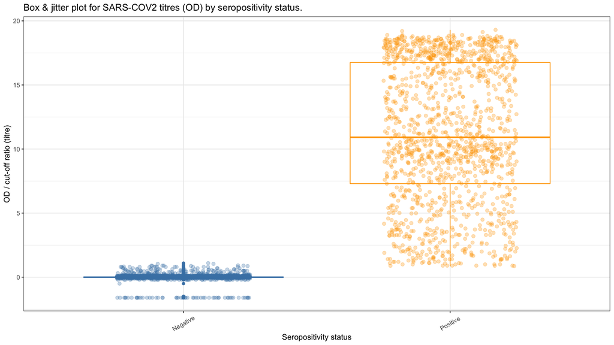

```r
g<-dat %>%
  ggplot(mapping=aes(x=results,y=ODCutoff,col=results)) +
  geom_boxplot() +
  geom_jitter(alpha=0.3,width=0.25,size=2) +
  scale_color_manual(values=c("steelblue","orange","salmon")) +
  guides(colour="none") +
  theme_bw() +
  xlab("Seropositivity status") +
  ylab("OD / cut-off ratio (titre)") +
  theme(axis.text.x = element_text(angle = 30, vjust = 0.5)) +
  labs(title="Box & jitter plot for SARS-COV2 titres (OD) by seropositivity status.") #+
  #geom_hline(mapping=aes(yintercept=1.1))

print(g)
```

```r
png(width=12,height=6.75,units="in",res=300,file=paste(sep="/",outDir,paste(sep="_",gsub(pattern="-",replacement="",Sys.Date()),"Fig1_BoxJitterPlot_ODvsInterpretation.png")))
print(g)
dev.off()
```

```r
datWHO<-list()

for(m in gsub("all",seq(ym("2020-01"),ym("2021-07"),by="month"),pattern="-01$",replacement="")){
  datWHO[[m]]<-data.frame(
    subGroup=c("All","Males","Females","15-19","20-29","30-39","40-49","50-59","60-64"),
    sampSize=NA,
    nSeroPos=NA,
    nSeroPosWithSymp=NA,
    comments=c(rep("Age range in MBTS data limited to 15-63",3),rep(NA,5),"Age range in MBTS data limited to 15-63"),
    propSeroPos=NA,
    propSeroPos95CILow=NA,
    propSeroPos95CIHigh=NA,
    propSeroPosWithSymp=NA,
    propSeroPosAdjSensSpec=NA,
    propSeroPosAdjSensSpec95CILow=NA,
    propSeroPosAdjSensSpec95CIHigh=NA,
    propSeroPosWeighted=NA,
    propSeroPosWeighted95CILow=NA,
    propSeroPosWeighted95CIHigh=NA,
    propSeroPosWeightedAdjSensSpec=NA,
    propSeroPosWeightedAdjSensSpec95CILow=NA,
    propSeroPosWeightedAdjSensSpec95CIHigh=NA
  )

  rownames(datWHO[[m]])<-datWHO[[m]]$subGroup

  if(m=="all"){
    datTmp<-dat
  }else{
    datTmp<-dat %>%
      dplyr::filter(month==m)
  }

  # populate counts and proportions
  datWHO[[m]]["All",c("sampSize","nSeroPos","propSeroPos","propSeroPosWeighted")]<-c(nrow(datTmp),sum(datTmp$seropos),sum(datTmp$seropos)/nrow(datTmp),sum(datTmp$seropos*datTmp$sampWeight)/sum(datTmp$sampWeight))
  datWHO[[m]]["Males",c("sampSize","nSeroPos","propSeroPos","propSeroPosWeighted")]<-c(sum(datTmp$gender=="Male"),sum(datTmp$seropos[datTmp$gender=="Male"]),sum(datTmp$seropos[datTmp$gender=="Male"])/sum(datTmp$gender=="Male"),sum(datTmp$seropos[datTmp$gender=="Male"]*datTmp$sampWeight[datTmp$gender=="Male"])/sum(datTmp$sampWeight[datTmp$gender=="Male"]))
  datWHO[[m]]["Females",c("sampSize","nSeroPos","propSeroPos","propSeroPosWeighted")]<-c(sum(datTmp$gender=="Female"),sum(datTmp$seropos[datTmp$gender=="Female"]),sum(datTmp$seropos[datTmp$gender=="Female"])/sum(datTmp$gender=="Female"),sum(datTmp$seropos[datTmp$gender=="Female"]*datTmp$sampWeight[datTmp$gender=="Female"])/sum(datTmp$sampWeight[datTmp$gender=="Female"]))
  datWHO[[m]]["15-19",c("sampSize","nSeroPos","propSeroPos","propSeroPosWeighted")]<-c(sum(datTmp$age_years>=15 & datTmp$age_years<=19),sum(datTmp$seropos[datTmp$age_years>=15 & datTmp$age_years<=19]),sum(datTmp$seropos[datTmp$age_years>=15 & datTmp$age_years<=19])/sum(datTmp$age_years>=15 & datTmp$age_years<=19),sum(datTmp$seropos[datTmp$age_years>=15 & datTmp$age_years<=19]*datTmp$sampWeight[datTmp$age_years>=15 & datTmp$age_years<=19])/sum(datTmp$sampWeight[datTmp$age_years>=15 & datTmp$age_years<=19]))
  datWHO[[m]]["20-29",c("sampSize","nSeroPos","propSeroPos","propSeroPosWeighted")]<-c(sum(datTmp$age_years>=20 & datTmp$age_years<=29),sum(datTmp$seropos[datTmp$age_years>=20 & datTmp$age_years<=29]),sum(datTmp$seropos[datTmp$age_years>=20 & datTmp$age_years<=29])/sum(datTmp$age_years>=20 & datTmp$age_years<=29),sum(datTmp$seropos[datTmp$age_years>=20 & datTmp$age_years<=29]*datTmp$sampWeight[datTmp$age_years>=20 & datTmp$age_years<=29])/sum(datTmp$sampWeight[datTmp$age_years>=20 & datTmp$age_years<=29]))
  datWHO[[m]]["30-39",c("sampSize","nSeroPos","propSeroPos","propSeroPosWeighted")]<-c(sum(datTmp$age_years>=30 & datTmp$age_years<=39),sum(datTmp$seropos[datTmp$age_years>=30 & datTmp$age_years<=39]),sum(datTmp$seropos[datTmp$age_years>=30 & datTmp$age_years<=39])/sum(datTmp$age_years>=30 & datTmp$age_years<=39),sum(datTmp$seropos[datTmp$age_years>=30 & datTmp$age_years<=39]*datTmp$sampWeight[datTmp$age_years>=30 & datTmp$age_years<=39])/sum(datTmp$sampWeight[datTmp$age_years>=30 & datTmp$age_years<=39]))
  datWHO[[m]]["40-49",c("sampSize","nSeroPos","propSeroPos","propSeroPosWeighted")]<-c(sum(datTmp$age_years>=40 & datTmp$age_years<=49),sum(datTmp$seropos[datTmp$age_years>=40 & datTmp$age_years<=49]),sum(datTmp$seropos[datTmp$age_years>=40 & datTmp$age_years<=49])/sum(datTmp$age_years>=40 & datTmp$age_years<=49),sum(datTmp$seropos[datTmp$age_years>=40 & datTmp$age_years<=49]*datTmp$sampWeight[datTmp$age_years>=40 & datTmp$age_years<=49])/sum(datTmp$sampWeight[datTmp$age_years>=40 & datTmp$age_years<=49]))
  datWHO[[m]]["50-59",c("sampSize","nSeroPos","propSeroPos","propSeroPosWeighted")]<-c(sum(datTmp$age_years>=50 & datTmp$age_years<=59),sum(datTmp$seropos[datTmp$age_years>=50 & datTmp$age_years<=59]),sum(datTmp$seropos[datTmp$age_years>=50 & datTmp$age_years<=59])/sum(datTmp$age_years>=50 & datTmp$age_years<=59),sum(datTmp$seropos[datTmp$age_years>=50 & datTmp$age_years<=59]*datTmp$sampWeight[datTmp$age_years>=50 & datTmp$age_years<=59])/sum(datTmp$sampWeight[datTmp$age_years>=50 & datTmp$age_years<=59]))
  datWHO[[m]]["60-64",c("sampSize","nSeroPos","propSeroPos","propSeroPosWeighted")]<-c(sum(datTmp$age_years>=60 & datTmp$age_years<=64),sum(datTmp$seropos[datTmp$age_years>=60 & datTmp$age_years<=64]),sum(datTmp$seropos[datTmp$age_years>=60 & datTmp$age_years<=64])/sum(datTmp$age_years>=60 & datTmp$age_years<=64),sum(datTmp$seropos[datTmp$age_years>=60 & datTmp$age_years<=64]*datTmp$sampWeight[datTmp$age_years>=60 & datTmp$age_years<=64])/sum(datTmp$sampWeight[datTmp$age_years>=60 & datTmp$age_years<=64]))

  # populate confidence intervals
  for(j in 1:nrow(datWHO[[m]])){
    if(!is.na(datWHO[[m]][j,"sampSize"]) & datWHO[[m]][j,"sampSize"]>0){
      datWHO[[m]][j,c("propSeroPos95CILow","propSeroPos95CIHigh")]<-binom.test(n=datWHO[[m]][j,"sampSize"],x=datWHO[[m]][j,"nSeroPos"])$conf.int
    }
  }

  # populate weighted confidence intervals
  if(!is.na(datWHO[[m]]["All","sampSize"]) & datWHO[[m]]["All","sampSize"]>0){datWHO[[m]]["All",c("propSeroPosWeighted95CILow","propSeroPosWeighted95CIHigh")]<-binom.test(n=nrow(datTmp),x=round(sum(datTmp$seropos*datTmp$sampWeight)*(nrow(datTmp)/sum(datTmp$sampWeight))))$conf.int}

  datTmp2<-datTmp %>% dplyr::filter(gender=="Male")
  if(!is.na(datWHO[[m]]["Males","sampSize"]) & datWHO[[m]]["Males","sampSize"]>0){datWHO[[m]]["Males",c("propSeroPosWeighted95CILow","propSeroPosWeighted95CIHigh")]<-binom.test(n=nrow(datTmp2),x=round(sum(datTmp2$seropos*datTmp2$sampWeight)*(nrow(datTmp2)/sum(datTmp2$sampWeight))))$conf.int}

  datTmp2<-datTmp %>% filter(gender=="Female")
  if(!is.na(datWHO[[m]]["Females","sampSize"]) & datWHO[[m]]["Females","sampSize"]>0){datWHO[[m]]["Females",c("propSeroPosWeighted95CILow","propSeroPosWeighted95CIHigh")]<-binom.test(n=nrow(datTmp2),x=round(sum(datTmp2$seropos*datTmp2$sampWeight)*(nrow(datTmp2)/sum(datTmp2$sampWeight))))$conf.int}

  datTmp2<-datTmp %>% dplyr::filter(age_years>=15 & age_years<=19)
  if(!is.na(datWHO[[m]]["15-19","sampSize"]) & datWHO[[m]]["15-19","sampSize"]>0){datWHO[[m]]["15-19",c("propSeroPosWeighted95CILow","propSeroPosWeighted95CIHigh")]<-binom.test(n=nrow(datTmp2),x=round(sum(datTmp2$seropos*datTmp2$sampWeight)*(nrow(datTmp2)/sum(datTmp2$sampWeight))))$conf.int}

  datTmp2<-datTmp %>% dplyr::filter(age_years>=20 & age_years<=29)
  if(!is.na(datWHO[[m]]["20-29","sampSize"]) & datWHO[[m]]["20-29","sampSize"]>0){datWHO[[m]]["20-29",c("propSeroPosWeighted95CILow","propSeroPosWeighted95CIHigh")]<-binom.test(n=nrow(datTmp2),x=round(sum(datTmp2$seropos*datTmp2$sampWeight)*(nrow(datTmp2)/sum(datTmp2$sampWeight))))$conf.int}

  datTmp2<-datTmp %>% dplyr::filter(age_years>=30 & age_years<=39)
  if(!is.na(datWHO[[m]]["30-39","sampSize"]) & datWHO[[m]]["30-39","sampSize"]>0){datWHO[[m]]["30-39",c("propSeroPosWeighted95CILow","propSeroPosWeighted95CIHigh")]<-binom.test(n=nrow(datTmp2),x=round(sum(datTmp2$seropos*datTmp2$sampWeight)*(nrow(datTmp2)/sum(datTmp2$sampWeight))))$conf.int}

  datTmp2<-datTmp %>% dplyr::filter(age_years>=40 & age_years<=49)
  if(!is.na(datWHO[[m]]["40-49","sampSize"]) & datWHO[[m]]["40-49","sampSize"]>0){datWHO[[m]]["40-49",c("propSeroPosWeighted95CILow","propSeroPosWeighted95CIHigh")]<-binom.test(n=nrow(datTmp2),x=round(sum(datTmp2$seropos*datTmp2$sampWeight)*(nrow(datTmp2)/sum(datTmp2$sampWeight))))$conf.int}

  datTmp2<-datTmp %>% dplyr::filter(age_years>=50 & age_years<=59)
  if(!is.na(datWHO[[m]]["50-59","sampSize"]) & datWHO[[m]]["50-59","sampSize"]>0){datWHO[[m]]["50-59",c("propSeroPosWeighted95CILow","propSeroPosWeighted95CIHigh")]<-binom.test(n=nrow(datTmp2),x=round(sum(datTmp2$seropos*datTmp2$sampWeight)*(nrow(datTmp2)/sum(datTmp2$sampWeight))))$conf.int}

  datTmp2<-datTmp %>% dplyr::filter(age_years>=60 & age_years<=64)
  if(!is.na(datWHO[[m]]["60-64","sampSize"]) & datWHO[[m]]["60-64","sampSize"]>0){datWHO[[m]]["60-64",c("propSeroPosWeighted95CILow","propSeroPosWeighted95CIHigh")]<-binom.test(n=nrow(datTmp2),x=round(sum(datTmp2$seropos*datTmp2$sampWeight)*(nrow(datTmp2)/sum(datTmp2$sampWeight))))$conf.int}


  # adjust for assay sensitivity and specificty
  for(j in 1:nrow(datWHO[[m]])){
    if(!is.na(datWHO[[m]]$sampSize[j]) & datWHO[[m]]$sampSize[j]>0){
      tmp<-adjPrevSensSpecCI(prevCI=c(datWHO[[m]]$propSeroPos95CILow[j],datWHO[[m]]$propSeroPos95CIHigh[j]),
                             sensCI=binom.test(assaySensInd[1],assaySensInd[2])$conf.int,
                             specCI=binom.test(assaySpecInd[1],assaySpecInd[2])$conf.int,
                             prev=datWHO[[m]]$propSeroPos[j],
                             sens=assaySensInd[1]/assaySensInd[2],
                             spec=assaySpecInd[1]/assaySpecInd[2],
                             N=1e5)
      datWHO[[m]]$propSeroPosAdjSensSpec[j]<-tmp$estimate
      datWHO[[m]]$propSeroPosAdjSensSpec95CILow[j]<-tmp$conf.int[1]
      datWHO[[m]]$propSeroPosAdjSensSpec95CIHigh[j]<-tmp$conf.int[2]

      tmp<-adjPrevSensSpecCI(prevCI=c(datWHO[[m]]$propSeroPosWeighted95CILow[j],datWHO[[m]]$propSeroPosWeighted95CIHigh[j]),
                             sensCI=binom.test(assaySensInd[1],assaySensInd[2])$conf.int,
                             specCI=binom.test(assaySpecInd[1],assaySpecInd[2])$conf.int,
                             prev=datWHO[[m]]$propSeroPosWeighted[j],
                             sens=assaySensInd[1]/assaySensInd[2],
                             spec=assaySpecInd[1]/assaySpecInd[2],
                             N=1e5)
      datWHO[[m]]$propSeroPosWeightedAdjSensSpec[j]<-tmp$estimate
      datWHO[[m]]$propSeroPosWeightedAdjSensSpec95CILow[j]<-tmp$conf.int[1]
      datWHO[[m]]$propSeroPosWeightedAdjSensSpec95CIHigh[j]<-tmp$conf.int[2]
    }
  }

  write.csv(datWHO[[m]],file=paste(sep="/",outDir,paste(sep="_",gsub(pattern="-",replacement="",Sys.Date()),paste(sep="","tableWHO_",m,".csv"))),row.names=F,quote=F)
}
```

## Flexible seroprevalence models

These will allow to include other covariates to explore associations and the model fits provide a smoothed estimate of the seroprevalence over time. We use Genersalised Additive Models (GAMs) with reduced rank, panlised thin plate splines to obtain the model fits.

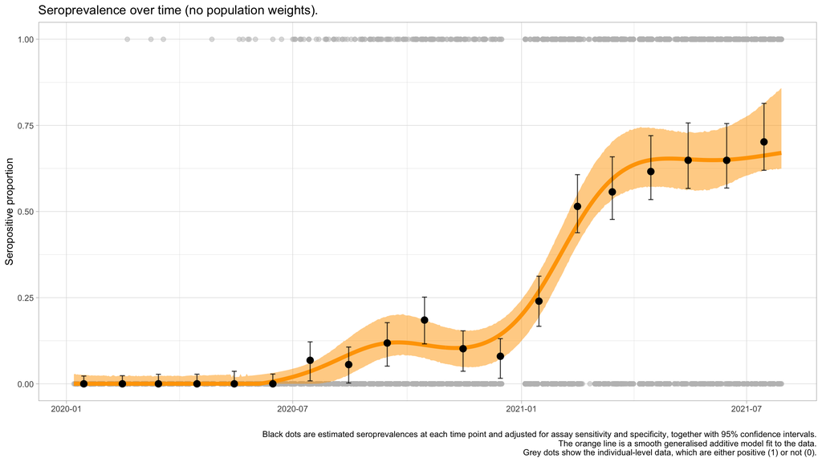

```r
dat$dateNum<-as.numeric(ymd(dat$date))

#modRcs<-glm(seropos~rcs(dateNum,7),data=dat,family="binomial")
modGam<-gam(seropos~s(dateNum,bs="tp"),data=dat,family="binomial")
modGamWeighted<-gam(seropos~s(dateNum,bs="tp"),data=dat,family="binomial",weights=sampWeight)
linkFunInv<-family(modGam)$linkinv

predDat<-data.frame(
  dateNum=min(dat$dateNum):max(dat$dateNum),
  date=seq(min(dat$date),max(dat$date),by=1)
)
predDatWeighted<-predDat

#predObjRcs<-predict(modRcs,newdata=predDat,type="link",se.fit=TRUE)
predObjGam<-predict(modGam,newdata=predDat,type="link",se.fit=TRUE)
predObjGamWeighted<-predict(modGamWeighted,newdata=predDat,type="link",se.fit=TRUE)

predDat<-cbind(
  predDat,
  #predObjRcs$fit,
  #predObjRcs$se.fit,
  predObjGam$fit,
  predObjGam$se.fit
)

predDatWeighted<-cbind(
  predDatWeighted,
  #predObjRcs$fit,
  #predObjRcs$se.fit,
  predObjGamWeighted$fit,
  predObjGamWeighted$se.fit
)

#colnames(predDat)<-c("dateNum","date","fit.rcs","se.fit.rcs","fit.gam","se.fit.gam")
colnames(predDat)<-c("dateNum","date","fit.gam","se.fit.gam")
colnames(predDatWeighted)<-c("dateNum","date","fit.gam","se.fit.gam")
predDat <- predDat %>%
  mutate(
    #seroprevRcs=linkFunInv(fit.rcs),
    #seroprevRcsLow=linkFunInv(fit.rcs-qnorm(0.975)*se.fit.rcs),
    #seroprevRcsUpp=linkFunInv(fit.rcs+qnorm(0.975)*se.fit.rcs),
    seroprevGam=linkFunInv(fit.gam),
    seroprevGamLow=linkFunInv(fit.gam-qnorm(0.975)*se.fit.gam),
    seroprevGamUpp=linkFunInv(fit.gam+qnorm(0.975)*se.fit.gam)
  )
predDatWeighted <- predDatWeighted %>%
  mutate(
    #seroprevRcs=linkFunInv(fit.rcs),
    #seroprevRcsLow=linkFunInv(fit.rcs-qnorm(0.975)*se.fit.rcs),
    #seroprevRcsUpp=linkFunInv(fit.rcs+qnorm(0.975)*se.fit.rcs),
    seroprevGam=linkFunInv(fit.gam),
    seroprevGamLow=linkFunInv(fit.gam-qnorm(0.975)*se.fit.gam),
    seroprevGamUpp=linkFunInv(fit.gam+qnorm(0.975)*se.fit.gam)
  )

predDat$seroprevGamAdj<-NA
predDat$seroprevGamAdjLow<-NA
predDat$seroprevGamAdjUpp<-NA
predDatWeighted$seroprevGamAdj<-NA
predDatWeighted$seroprevGamAdjLow<-NA
predDatWeighted$seroprevGamAdjUpp<-NA

for(i in 1:nrow(predDat)){
  tmp<-adjPrevSensSpecCI(prevCI=c(predDat$seroprevGamLow[i],predDat$seroprevGamUpp[i]),
                         sensCI=binom.test(assaySensInd[1],assaySensInd[2])$conf.int,
                         specCI=binom.test(assaySpecInd[1],assaySpecInd[2])$conf.int,
                         prev=predDat$seroprevGam[i],
                         sens=assaySensInd[1]/assaySensInd[2],
                         spec=assaySpecInd[1]/assaySpecInd[2],
                         N=1e5)
  predDat$seroprevGamAdj[i]<-tmp$estimate
  predDat$seroprevGamAdjLow[i]<-tmp$conf.int[1]
  predDat$seroprevGamAdjUpp[i]<-tmp$conf.int[2]

  tmp<-adjPrevSensSpecCI(prevCI=c(predDatWeighted$seroprevGamLow[i],predDatWeighted$seroprevGamUpp[i]),
                         sensCI=binom.test(assaySensInd[1],assaySensInd[2])$conf.int,
                         specCI=binom.test(assaySpecInd[1],assaySpecInd[2])$conf.int,
                         prev=predDatWeighted$seroprevGam[i],
                         sens=assaySensInd[1]/assaySensInd[2],
                         spec=assaySpecInd[1]/assaySpecInd[2],
                         N=1e5)
  predDatWeighted$seroprevGamAdj[i]<-tmp$estimate
  predDatWeighted$seroprevGamAdjLow[i]<-tmp$conf.int[1]
  predDatWeighted$seroprevGamAdjUpp[i]<-tmp$conf.int[2]
}

# predDat$seroprevGamAdjLow[predDat$seroprevGamAdjLow<=0 | predDat$seroprevGamAdj<=0]<-0
# predDat$seroprevGamAdj[predDat$seroprevGamAdj<=0]<-0

g<-dat %>%
  ggplot(mapping=aes(x=date,y=seropos)) +
  geom_point(alpha=0.5,col="grey",size=2) +
  geom_line(col="orange",mapping=aes(x=date,y=seroprevGamAdj),data=predDat,lwd=2) +
  geom_ribbon(col=NA,fill="orange",alpha=0.5,mapping=aes(x=date,y=seroprevGamAdj,ymin=seroprevGamAdjLow,ymax=seroprevGamAdjUpp),data=predDatWeighted,lwd=2) +
  geom_point(mapping=aes(x=ymd(paste(sep="-",month,"15")),y=seropospropAdj),col="black",size=3,data=datPropMonthSampWeight) +
  geom_errorbar(mapping=aes(x=ymd(paste(sep="-",month,"15")),y=seropospropAdj,ymin=seropospropAdjLow,ymax=seropospropAdjHigh),col="black",width=4,alpha=0.75,data=datPropMonthSampWeight) +
  theme_light() +
  ylab("Seropositive proportion") +
  xlab("") +
  labs(title="Seroprevalence over time (no population weights).",caption="Black dots are estimated seroprevalences at each time point and adjusted for assay sensitivity and specificity, together with 95% confidence intervals.\nThe orange line is a smooth generalised additive model fit to the data.\nGrey dots show the individual-level data, which are either positive (1) or not (0).")

print(g)
```

```r
png(width=12,height=6.75,units="in",res=300,file=paste(sep="/",outDir,paste(sep="_",gsub(pattern="-",replacement="",Sys.Date()),"Fig1a_GAMFit_AllSamples.png")))
print(g)
dev.off()
```

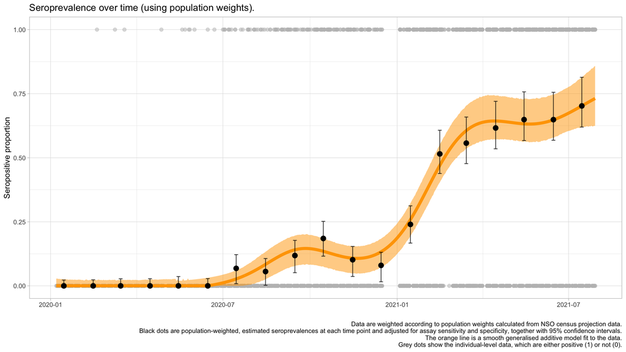

```r
gW<-dat %>%
  ggplot(mapping=aes(x=date,y=seropos)) +
  geom_point(alpha=0.5,col="grey",size=2) +
  geom_line(col="orange",mapping=aes(x=date,y=seroprevGamAdj),data=predDatWeighted,lwd=2) +
  geom_ribbon(col=NA,fill="orange",alpha=0.5,mapping=aes(x=date,y=seroprevGamAdj,ymin=seroprevGamAdjLow,ymax=seroprevGamAdjUpp),data=predDatWeighted,lwd=2) +
  geom_point(mapping=aes(x=ymd(paste(sep="-",month,"15")),y=seropospropAdj),col="black",size=3,data=datPropMonthSampWeight) +
  geom_errorbar(mapping=aes(x=ymd(paste(sep="-",month,"15")),y=seropospropAdj,ymin=seropospropAdjLow,ymax=seropospropAdjHigh),col="black",width=4,alpha=0.75,data=datPropMonthSampWeight) +
  theme_light() +
  ylab("Seropositive proportion") +
  xlab("") +
  labs(title="Seroprevalence over time (using population weights).",caption="Data are weighted according to population weights calculated from NSO census projection data.\nBlack dots are population-weighted, estimated seroprevalences at each time point and adjusted for assay sensitivity and specificity, together with 95% confidence intervals.\nThe orange line is a smooth generalised additive model fit to the data.\nGrey dots show the individual-level data, which are either positive (1) or not (0).")

print(gW)
```

```r
png(width=12,height=6.75,units="in",res=300,file=paste(sep="/",outDir,paste(sep="_",gsub(pattern="-",replacement="",Sys.Date()),"Fig1a_GAMFit_AllSamples_WithSampleWeights.png")))
print(gW)
dev.off()
```

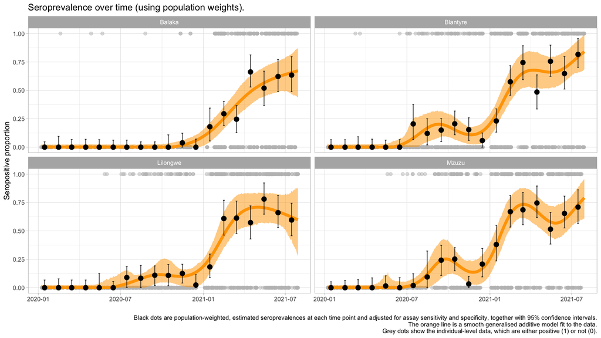

```r
predDatStratList<-list()

for(pl in unique(dat$location)){
  predDatTmp<-data.frame(
    location=rep(pl,length(min(dat$dateNum):max(dat$dateNum))),
    dateNum=min(dat$dateNum):max(dat$dateNum),
    date=seq(min(dat$date),max(dat$date),by=1)
  )

  modGamWeighted<-gam(seropos~s(dateNum,bs="tp"),data=dat %>% dplyr::filter(location==pl),family="binomial",weights = sampWeight)
  linkFunInv<-family(modGamWeighted)$linkinv

  predObjGamWeighted<-predict(modGamWeighted,newdata=predDatTmp,type="link",se.fit=TRUE)

  predDatTmp<-cbind(
    predDatTmp,
    predObjGamWeighted$fit,
    predObjGamWeighted$se.fit
  )

  B<-10000 # 1000 bootstrap samples
  set.seed(123) # for reproducibility
  predDatTmp2<-predDatTmp[,1:3]
  for(b in 1:B){
    modGamWeightedBoot<-gam(seropos~s(dateNum,bs="tp"),data=dat[sample(1:nrow(dat),size=nrow(dat),replace=T),] %>% dplyr::filter(location==pl),family="binomial",weights = sampWeight)
    predObjGamWeightedBoot<-predict(modGamWeightedBoot,newdata=predDatTmp,type="link",se.fit=FALSE)
    predDatTmp2<-cbind(predDatTmp2,predObjGamWeightedBoot)
  }

  colnames(predDatTmp)<-c("location","dateNum","date","fit.gam","se.fit.gam")
  predDatTmp <- predDatTmp %>%
    mutate(
      seroprevGam=linkFunInv(fit.gam),
      #seroprevGamLow=linkFunInv(fit.gam-qnorm(0.975)*se.fit.gam),
      #seroprevGamUpp=linkFunInv(fit.gam+qnorm(0.975)*se.fit.gam)
      seroprevGamLow=NA,
      seroprevGamUpp=NA,
    )

  for(j in 1:nrow(predDatTmp)){
    tmp<-HDInterval::hdi(as.numeric(predDatTmp2[j,-(1:3)]))
    predDatTmp$seroprevGamLow[j]<-linkFunInv(tmp[1])
    predDatTmp$seroprevGamUpp[j]<-linkFunInv(tmp[2])
  }
  rm(predDatTmp2)

  predDatTmp$seroprevGamAdj<-NA
  predDatTmp$seroprevGamAdjLow<-NA
  predDatTmp$seroprevGamAdjUpp<-NA

  for(i in 1:nrow(predDatTmp)){
    tmp<-adjPrevSensSpecCI(prevCI=c(predDatTmp$seroprevGamLow[i],predDatTmp$seroprevGamUpp[i]),
                           sensCI=binom.test(assaySensInd[1],assaySensInd[2])$conf.int,
                           specCI=binom.test(assaySpecInd[1],assaySpecInd[2])$conf.int,
                           prev=predDatTmp$seroprevGam[i],
                           sens=assaySensInd[1]/assaySensInd[2],
                           spec=assaySpecInd[1]/assaySpecInd[2],
                           N=1e5)
    predDatTmp$seroprevGamAdj[i]<-tmp$estimate
    predDatTmp$seroprevGamAdjLow[i]<-tmp$conf.int[1]
    predDatTmp$seroprevGamAdjUpp[i]<-tmp$conf.int[2]
  }

  predDatTmp$seroprevGamAdjLow[predDatTmp$seroprevGamAdjLow<=0 | predDatTmp$seroprevGamAdj<=0]<-0
  predDatTmp$seroprevGamAdj[predDatTmp$seroprevGamAdj<=0]<-0

  predDatStratList[[pl]]<-predDatTmp
  rm(predDatTmp)
}

predDatStrat<-predDatStratList[[1]]
for(j in 2:length(predDatStratList)){
  predDatStrat<-rbind(predDatStrat,predDatStratList[[j]])
}
rm(predDatStratList)

gStrat<-dat %>%
  ggplot(mapping=aes(x=date,y=seropos)) +
  geom_point(alpha=0.5,col="grey",size=2) +
  geom_line(col="orange",mapping=aes(x=date,y=seroprevGamAdj),data=predDatStrat,lwd=2) +
  geom_ribbon(col=NA,fill="orange",alpha=0.5,mapping=aes(x=date,y=seroprevGamAdj,ymin=seroprevGamAdjLow,ymax=seroprevGamAdjUpp),data=predDatStrat,lwd=2) +
  geom_point(mapping=aes(x=ymd(paste(sep="-",month,"15")),y=seropospropAdj),col="black",size=3,data=datPropStratSampWeight) +
  geom_errorbar(mapping=aes(x=ymd(paste(sep="-",month,"15")),y=seropospropAdj,ymin=seropospropAdjLow,ymax=seropospropAdjHigh),col="black",width=4,alpha=0.75,data=datPropStratSampWeight) +
  theme_light() +
  ylab("Seropositive proportion") +
  xlab("") +
  facet_wrap(~location) +
  labs(title="Seroprevalence over time (using population weights).",caption="Black dots are population-weighted, estimated seroprevalences at each time point and adjusted for assay sensitivity and specificity, together with 95% confidence intervals.\nThe orange line is a smooth generalised additive model fit to the data.\nGrey dots show the individual-level data, which are either positive (1) or not (0).")

print(gStrat)
```

```r
png(width=12,height=6.75,units="in",res=300,file=paste(sep="/",outDir,paste(sep="_",gsub(pattern="-",replacement="",Sys.Date()),"Fig2b_GAMFit_StratifiedByLocation.png")))
print(gStrat)
dev.off()
```

A GAM model with covariates:

```r
modGam<-gam(seropos~s(dateNum,bs="tp")+gender+location+s(age,bs="tp"),data=dat,family="binomial",weights = sampWeight)
summary(modGam)
```

```
##
## Family: binomial
## Link function: logit
##
## Formula:
## seropos ~ s(dateNum, bs = "tp") + gender + location + s(age,
##     bs = "tp")
##
## Parametric coefficients:
##                  Estimate Std. Error z value Pr(>|z|)
## (Intercept)      -2.68187    0.22219 -12.070  < 2e-16 ***
## genderMale        0.06097    0.08746   0.697    0.486
## locationBlantyre  0.89781    0.13122   6.842 7.81e-12 ***
## locationLilongwe  0.68067    0.13207   5.154 2.55e-07 ***
## locationMzuzu     0.95636    0.13581   7.042 1.89e-12 ***
## ---
## Signif. codes:  0 '***' 0.001 '**' 0.01 '*' 0.05 '.' 0.1 ' ' 1
##
## Approximate significance of smooth terms:
##              edf Ref.df  Chi.sq p-value
## s(dateNum) 7.223  7.945 724.212  <2e-16 ***
## s(age)     1.002  1.004   0.993   0.321
## ---
## Signif. codes:  0 '***' 0.001 '**' 0.01 '*' 0.05 '.' 0.1 ' ' 1
##
## R-sq.(adj) =  0.331   Deviance explained = 31.2%
## UBRE = -0.36566  Scale est. = 1         n = 5085
```

And a more traditional logistic regression model, but using B-splines for time and using age groups rather than exact age - very similar results.

```r
dat<-dat %>%
  mutate(
    ageGrp=case_when(
      age<20~"16-19",
      age>=20 & age<30~"20-29",
      age>=30 & age<40~"30-39",
      age>=40 & age<50~"40-49",
      age>=50~"50+"
    )
  )

mod<-glm(seropos~gender+ageGrp+location+bs(ymd(date)),data=dat,family="binomial",weights = sampWeight)


tt<-summary(mod)$coefficients
rownames(tt)<-c("(Intercept)","Male sex","20-29 years","30-39 years","40-49 years","50+ years","Blantyre","Lilongwe","Mzuzu","B-spline coefficient 1, time","B-spline coefficient 2, time","B-spline coefficient 3, time")

tt %>%
  as.data.frame() %>%
  #mutate(rownum=1:nrow(tt)) %>%
  #mutate(`Pr(>|z|)`=ifelse(rownum>1 & `Pr(>|z|)`<0.05,cell_spec(format(nsmall=4,round(digits=4,`Pr(>|z|)`)),bold=T),cell_spec(format(nsmall=4,round(digits=4,`Pr(>|z|)`)),bold=F))) %>%
  #dplyr::select(!c(rownum)) %>%
  kable(caption="Results from a multivariable logistic regression model using B-splines to account for the effect of time. Observations have been weighted using population weights.",digits=2) %>%
  column_spec(5,bold=ifelse(1:nrow(tt)>1 & tt[,"Pr(>|z|)"]<0.05,TRUE,FALSE)) %>%
  kable_styling(full_width=F)
```

Results from a multivariable logistic regression model using B-splines to account for the effect of time. Observations have been weighted using population weights.

|  | Estimate | Std. Error | z value | Pr(>\|z\|) |
| --- | --- | --- | --- | --- |
| (Intercept) | -6.12 | 0.76 | -8.11 | 0.00 |
| Male sex | 0.05 | 0.09 | 0.58 | 0.56 |
| 20-29 years | -0.04 | 0.11 | -0.32 | 0.75 |
| 30-39 years | -0.01 | 0.13 | -0.06 | 0.95 |
| 40-49 years | 0.16 | 0.15 | 1.04 | 0.30 |
| 50+ years | 0.20 | 0.38 | 0.53 | 0.60 |
| Blantyre | 0.77 | 0.13 | 5.92 | 0.00 |
| Lilongwe | 0.60 | 0.13 | 4.56 | 0.00 |
| Mzuzu | 0.86 | 0.13 | 6.41 | 0.00 |
| B-spline coefficient 1, time | 1.46 | 1.34 | 1.09 | 0.27 |
| B-spline coefficient 2, time | 6.06 | 0.63 | 9.65 | 0.00 |
| B-spline coefficient 3, time | 6.37 | 0.80 | 7.95 | 0.00 |

## Map bubble plots

Seroprevalence bubble plot for estimated, population-weighted seroprevalence by location and at specific timepoints.

```r
malawi<-readRDS(malawiDatFile)
#malawi_utm<-spTransform(malawi, CRS("+proj=utm"))
malawiDf<-fortify(malawi)

lakes<-read_sf("../../GIS/ne_50m_lakes/ne_50m_lakes.shp")
lakesMw<-lakes %>% dplyr::filter(grepl(pattern="Malawi",name))

theme_opts<-list(theme(panel.grid.minor = element_blank(),
                       panel.grid.major = element_blank(),
                       panel.background = element_blank(),
                       plot.background = element_blank(),
                       axis.line = element_blank(),
                       axis.text.x = element_blank(),
                       axis.text.y = element_blank(),
                       axis.ticks = element_blank(),
                       axis.title.x = element_blank(),
                       axis.title.y = element_blank()
                       #plot.title = element_blank())
))

cities<-data.frame(
  name=c("Balaka","Blantyre","Lilongwe","Mzuzu"),
  lon=c(34.9562,35.0168,33.7741,34.0084),
  lat=c(-14.9876,-15.7667,-13.9626,-11.4390),
  seroprev=NA
)

tmp<-datPropStratSampWeight %>%
  dplyr::filter(month=="2020-04") %>%
  dplyr::select(location,seropospropAdj)

cities$seroprev<-tmp$seropospropAdj[match(cities$name,tmp$location)]

gApr20<-ggplot() +
  geom_polygon(data=malawiDf, aes(long,lat,group=group), fill="whitesmoke")+
  geom_path(data=malawiDf, aes(long,lat, group=group), color="grey",size=0.1) +
  geom_sf(data = lakesMw, size=0.25, color=NA,fill="lightblue") +
  geom_circle(mapping=aes(x0=lon,y0=lat,r=1.25*seroprev),alpha=0.5,col=NA,fill="orange",data=cities) +
  geom_text(mapping=aes(x=lon,y=lat,label=name),data=cities) +
  guides() +
  coord_sf() +
  theme_opts +
  ggtitle("April 2020.")

tmp<-datPropStratSampWeight %>%
  dplyr::filter(month=="2020-07") %>%
  dplyr::select(location,seropospropAdj)

cities$seroprev<-tmp$seropospropAdj[match(cities$name,tmp$location)]

gJul20<-ggplot() +
  geom_polygon(data=malawiDf, aes(long,lat,group=group), fill="whitesmoke")+
  geom_path(data=malawiDf, aes(long,lat, group=group), color="grey",size=0.1) +
  geom_sf(data = lakesMw, size=0.25, color=NA,fill="lightblue") +
  geom_circle(mapping=aes(x0=lon,y0=lat,r=1.25*seroprev),alpha=0.5,col=NA,fill="orange",data=cities) +
  geom_text(mapping=aes(x=lon,y=lat,label=name),data=cities) +
  guides() +
  coord_sf() +
  theme_opts +
  ggtitle("July 2020.")

tmp<-datPropStratSampWeight %>%
  dplyr::filter(month=="2020-10") %>%
  dplyr::select(location,seropospropAdj)

cities$seroprev<-tmp$seropospropAdj[match(cities$name,tmp$location)]

gOct20<-ggplot() +
  geom_polygon(data=malawiDf, aes(long,lat,group=group), fill="whitesmoke")+
  geom_path(data=malawiDf, aes(long,lat, group=group), color="grey",size=0.1) +
  geom_sf(data = lakesMw, size=0.25, color=NA,fill="lightblue") +
  geom_circle(mapping=aes(x0=lon,y0=lat,r=1.25*seroprev),alpha=0.5,col=NA,fill="orange",data=cities) +
  geom_text(mapping=aes(x=lon,y=lat,label=name),data=cities) +
  guides() +
  coord_sf() +
  theme_opts +
  ggtitle("October 2020.")

tmp<-datPropStratSampWeight %>%
  dplyr::filter(month=="2021-01") %>%
  dplyr::select(location,seropospropAdj)

cities$seroprev<-tmp$seropospropAdj[match(cities$name,tmp$location)]

gJan21<-ggplot() +
  geom_polygon(data=malawiDf, aes(long,lat,group=group), fill="whitesmoke")+
  geom_path(data=malawiDf, aes(long,lat, group=group), color="grey",size=0.1) +
  geom_sf(data = lakesMw, size=0.25, color=NA,fill="lightblue") +
  geom_circle(mapping=aes(x0=lon,y0=lat,r=1.25*seroprev),alpha=0.5,col=NA,fill="orange",data=cities) +
  geom_text(mapping=aes(x=lon,y=lat,label=name),data=cities) +
  guides() +
  coord_sf() +
  theme_opts +
  ggtitle("January 2021.")

tmp<-datPropStratSampWeight %>%
  dplyr::filter(month=="2021-04") %>%
  dplyr::select(location,seropospropAdj)

cities$seroprev<-tmp$seropospropAdj[match(cities$name,tmp$location)]

gApr21<-ggplot() +
  geom_polygon(data=malawiDf, aes(long,lat,group=group), fill="whitesmoke")+
  geom_path(data=malawiDf, aes(long,lat, group=group), color="grey",size=0.1) +
  geom_sf(data = lakesMw, size=0.25, color=NA,fill="lightblue") +
  geom_circle(mapping=aes(x0=lon,y0=lat,r=1.25*seroprev),alpha=0.5,col=NA,fill="orange",data=cities) +
  geom_text(mapping=aes(x=lon,y=lat,label=name),data=cities) +
  guides() +
  coord_sf() +
  theme_opts +
  ggtitle("April 2021.")

tmp<-datPropStratSampWeight %>%
  dplyr::filter(month=="2021-07") %>%
  dplyr::select(location,seropospropAdj)

cities$seroprev<-tmp$seropospropAdj[match(cities$name,tmp$location)]

gJul21<-ggplot() +
  geom_polygon(data=malawiDf, aes(long,lat,group=group), fill="whitesmoke")+
  geom_path(data=malawiDf, aes(long,lat, group=group), color="grey",size=0.1) +
  geom_sf(data = lakesMw, size=0.25, color=NA,fill="lightblue") +
  geom_circle(mapping=aes(x0=lon,y0=lat,r=1.25*seroprev),alpha=0.5,col=NA,fill="orange",data=cities) +
  geom_text(mapping=aes(x=lon,y=lat,label=name),data=cities) +
  guides() +
  coord_sf() +
  theme_opts +
  ggtitle("July 2021.")
```

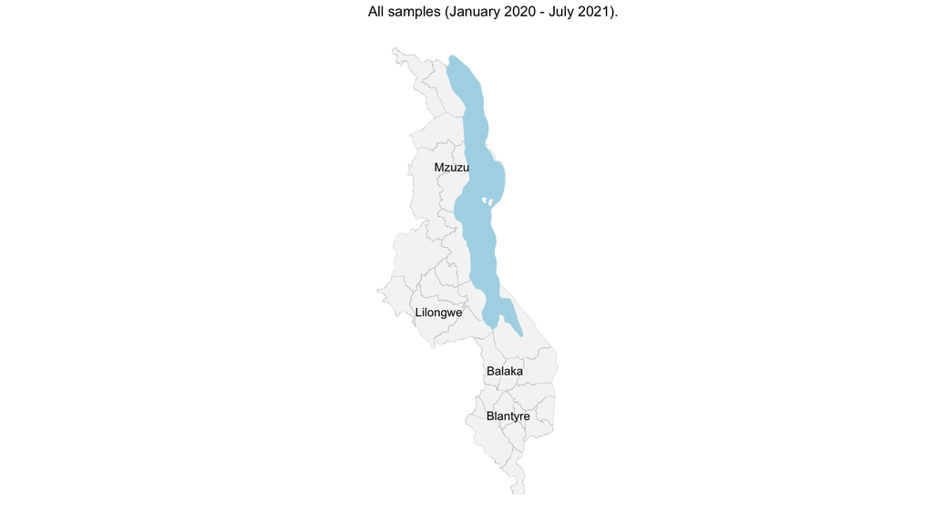

```r
datProp<-dat %>%
  group_by(location) %>%
  dplyr::summarise(seroposprop=mean(seropos*sampWeight)/sum(sampWeight),
            seropospropLow=binom.test(x=round(sum(seropos*sampWeight)*(n()/sum(sampWeight))),n=n())$conf.int[1],
            seropospropHigh=binom.test(x=round(sum(seropos*sampWeight)*(n()/sum(sampWeight))),n=n())$conf.int[2],.groups="drop")

datProp$seropospropAdj<-NA
datProp$seropospropAdjLow<-NA
datProp$seropospropAdjHigh<-NA

for(i in 1:nrow(datProp)){
  tmp<-adjPrevSensSpecCI(prevCI=c(datProp$seropospropLow[i],datProp$seropospropHigh[i]),
                         sensCI=binom.test(assaySensInd[1],assaySensInd[2])$conf.int,
                         specCI=binom.test(assaySpecInd[1],assaySpecInd[2])$conf.int,
                         prev=datProp$seroposprop[i],
                         sens=assaySensInd[1]/assaySensInd[2],
                         spec=assaySpecInd[1]/assaySpecInd[2],
                         N=1e5)
  datProp$seropospropAdj[i]<-tmp$estimate
  datProp$seropospropAdjLow[i]<-tmp$conf.int[1]
  datProp$seropospropAdjHigh[i]<-tmp$conf.int[2]
}

datProp$seropospropAdjLow[datProp$seropospropAdjLow<=0 | datProp$seropospropAdj<=0]<-0
datProp$seropospropAdj[datProp$seropospropAdj<=0]<-0

cities$seroprev<-datProp$seropospropAdj[match(cities$name,datProp$location)]

gAll<-ggplot() +
  geom_polygon(data=malawiDf, aes(long,lat,group=group), fill="whitesmoke")+
  geom_path(data=malawiDf, aes(long,lat, group=group), color="grey",size=0.1) +
  geom_sf(data = lakesMw, size=0.25, color=NA,fill="lightblue") +
  geom_circle(mapping=aes(x0=lon,y0=lat,r=1.25*seroprev),alpha=0.5,col=NA,fill="orange",data=cities) +
  geom_text(mapping=aes(x=lon,y=lat,label=name),data=cities) +
  guides() +
  coord_sf() +
  theme_opts +
  ggtitle("All samples (January 2020 - July 2021).")


print(gAll)
```

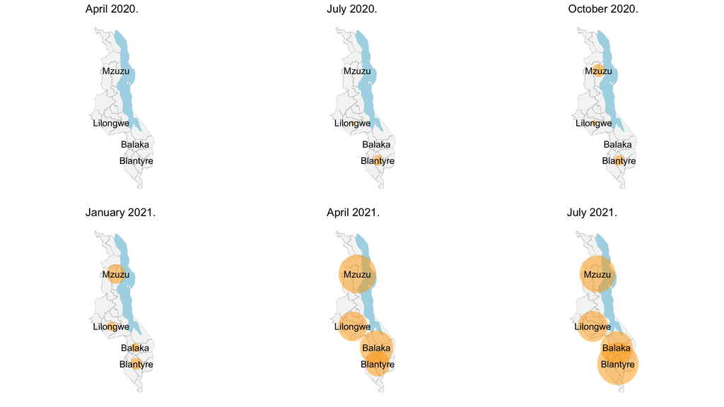

```r
grid.arrange(nrow=2,gApr20,gJul20,gOct20,gJan21,gApr21,gJul21)
```

```r
png(width=6,height=12,units="in",res=300,file=paste(sep="/",outDir,paste(sep="_",gsub(pattern="-",replacement="",Sys.Date()),"Fig3a_BubblePlot_AllSamples.png")))
print(gAll)
dev.off()

png(width=6,height=12,units="in",res=300,file=paste(sep="/",outDir,paste(sep="_",gsub(pattern="-",replacement="",Sys.Date()),"Fig3b_BubblePlot_April20.png")))
print(gApr20)
dev.off()

png(width=6,height=12,units="in",res=300,file=paste(sep="/",outDir,paste(sep="_",gsub(pattern="-",replacement="",Sys.Date()),"Fig3c_BubblePlot_July20.png")))
print(gJul20)
dev.off()

png(width=6,height=12,units="in",res=300,file=paste(sep="/",outDir,paste(sep="_",gsub(pattern="-",replacement="",Sys.Date()),"Fig3d_BubblePlot_October20.png")))
print(gOct20)
dev.off()

png(width=6,height=12,units="in",res=300,file=paste(sep="/",outDir,paste(sep="_",gsub(pattern="-",replacement="",Sys.Date()),"Fig3e_BubblePlot_January21.png")))
print(gJan21)
dev.off()

png(width=6,height=12,units="in",res=300,file=paste(sep="/",outDir,paste(sep="_",gsub(pattern="-",replacement="",Sys.Date()),"Fig3f_BubblePlot_April21.png")))
print(gApr21)
dev.off()

png(width=6,height=12,units="in",res=300,file=paste(sep="/",outDir,paste(sep="_",gsub(pattern="-",replacement="",Sys.Date()),"Fig3g_BubblePlot_July21.png")))
print(gJul21)
dev.off()

png(width=12,height=6.75,units="in",res=300,file=paste(sep="/",outDir,paste(sep="_",gsub(pattern="-",replacement="",Sys.Date()),"Fig3_BubblePlot_July2020Juy2021.png")))
grid.arrange(nrow=2,gApr20,gJul20,gOct20,gJan21,gApr21,gJul21)
dev.off()
```